# GlobalGeoTree Dataset Analysis

## 7.2 Global overview

Figure 3 projects a reproducible subsample of observations on a world map, and Figure 4 quantifies the total per continent. Figure 5 then resolves density *within* continents, separating a continent sampled evenly across its territory from one where the same volume sits in a few localised hotspots.

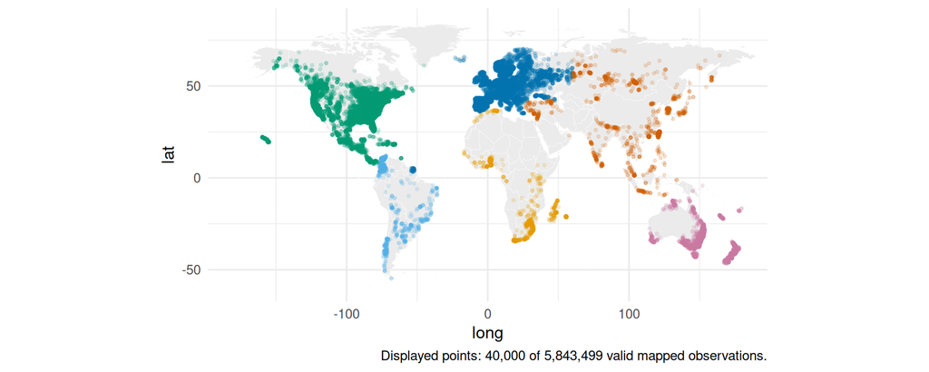

Figure 3: Geographical projection of observations by continent

```r
world_map <- if (exists("world_outline_plot")) {
  world_outline_plot
} else {
  map_data("world") |>
    filter(region != "Antarctica")
}


 ggplot() +

  geom_polygon(data = world_map,
               aes(long, lat, group = group),
               fill = "grey92", colour = "white", linewidth = 0.1) +

  geom_point(data = df_world_map_sample,
             aes(longitude, latitude, colour = continent),
             alpha = 0.15, size = 0.8) +

  scale_color_manual(values = continent_colors, guide = "none") +

  coord_fixed(1.3, xlim = c(-180, 180), ylim = c(-60, 85)) +

  plot_labs(caption = paste("Displayed points:", format_number(nrow(df_world_map_sample)), "of", format_number(nrow(df_world_map_base)), "valid mapped observations.")) +

  theme_minimal(base_size = 13)
```

Figure 3 shows a strongly uneven geographical coverage of observations. North America (green) and Europe (blue) display a dense, near-continuous coverage, closely following major population centres and road networks (a pattern typical of citizen-science platforms like iNaturalist, where sampling effort is driven by observer density rather than tree distribution alone). Asia (orange) covers a considerable geographical extent, but coverage is markedly uneven: it is dense in East Asia, India, and along the Trans-Siberian corridor, yet visibly sparse across Central Asia and Siberia’s interior. Africa (yellow) shows a similar contrast, with observations concentrated in South Africa, East Africa, and coastal West Africa, while the Congo Basin and the Sahara remain largely unsampled. South America (light blue) is dominated by coastal Brazil and the Andean corridor, with the Amazon interior almost entirely absent from the dataset despite hosting one of the highest levels of tree biodiversity on Earth. Oceania (pink) is essentially limited to Australia’s populated coastline and a scattering of Pacific islands. Overall, this map already suggests that observation density mirrors human accessibility and citizen-science activity more closely than it reflects actual tree biodiversity.

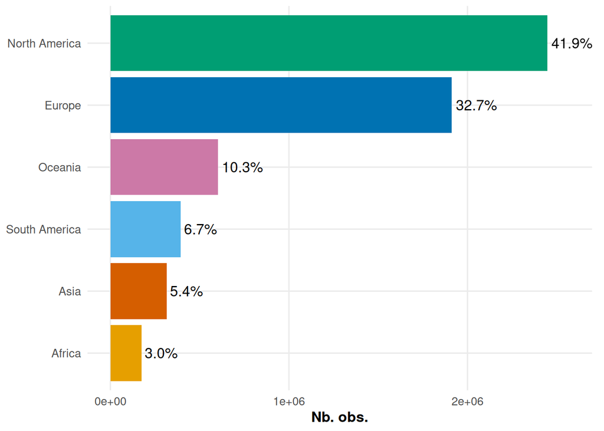

Figure 4: Total number of observations by continent

```r
df_n_obs <- df %>%
  count(continent, sort = TRUE) %>%
  mutate(
    percentage = n / sum(n),
    label = scales::percent(percentage, accuracy = 0.1)
  )


ggplot(df_n_obs, aes(x = reorder(continent, n), y = n)) +

  geom_col(aes(fill = continent)) +

  scale_fill_manual(values = continent_colors) +

  geom_text(
    aes(label = label),
    hjust = -0.1
  ) +

  expand_limits(y = max(df_n_obs$n) * 1.05) +

  coord_flip() +

  plot_labs(
    x = NULL,
    y = "Nb. obs."
  ) +

  theme_gtree() +

  theme(legend.position = "none")
```

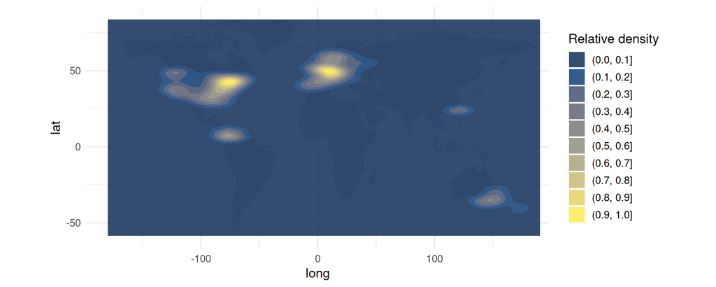

Figure 5: Geographical density of observations

```r
set.seed(map_sample_seed)
df_density <- df[is.finite(df$longitude) & is.finite(df$latitude), ]
df_density <- df_density[sample(nrow(df_density), min(density_map_sample_n, nrow(df_density))), ]

ggplot() +

  # Base map
  geom_polygon(
    data = world_map,
    aes(x = long, y = lat, group = group),
    fill = "grey90", colour = "white", linewidth = 0.1
  ) +

  # 2D density
  geom_density_2d_filled(
    data = df_density,
    aes(x = longitude, y = latitude),
    contour_var = "ndensity",
    alpha = 0.8
  ) +

  scale_fill_viridis_d(
    option = "cividis",
    name = "Relative density"
  ) +

  coord_fixed(1.3, xlim = c(-180, 180), ylim = c(-60, 85)) +

  theme_minimal(base_size = 13)
```

Figure 5 reveals that observations are not only concentrated on certain continents, but highly clustered within a small number of localised hotspots. The most intense concentration is found in Western Europe (particularly around France, Germany and the United Kingdom), followed closely by the northeastern United States. Secondary hotspots appear along the US West Coast, in Central America, in southeastern Australia, and around Taiwan / southern Japan, while the vast majority of the remaining land surface, including most of Africa, Asia and South America, shows minimal to no density. This reinforces the hypothesis raised earlier: sampling effort appears strongly correlated with population density and citizen-science activity rather than with the underlying distribution of tree biodiversity. Even within high-observation continents such as North America (Figure 4), density is far from uniform — observations concentrate along the East and West Coasts, while large inland areas remain comparatively under-sampled.

## 7.3 Spatial distribution of foliage types

Each tree in the dataset is classified into one of four foliage types (Evergreen Broadleaf, Evergreen Needleleaf, Deciduous Broadleaf, or Deciduous Needleleaf). This classification is closely tied to climate, since foliage strategy reflects how trees adapt to seasonal variation in temperature and water availability. The question is whether these types are distributed uniformly across the sampled regions or follow the climatic gradients expected from ecological theory, and whether that pattern is still visible despite the sampling bias identified above.

Figure 6 maps a subsample of observations for each foliage type and Figure 7 compares foliage composition across continents. Figure 8 then drops continental boundaries altogether for a continuous latitudinal gradient, since climate — and therefore foliage strategy — is structured by latitude rather than by administrative divisions.

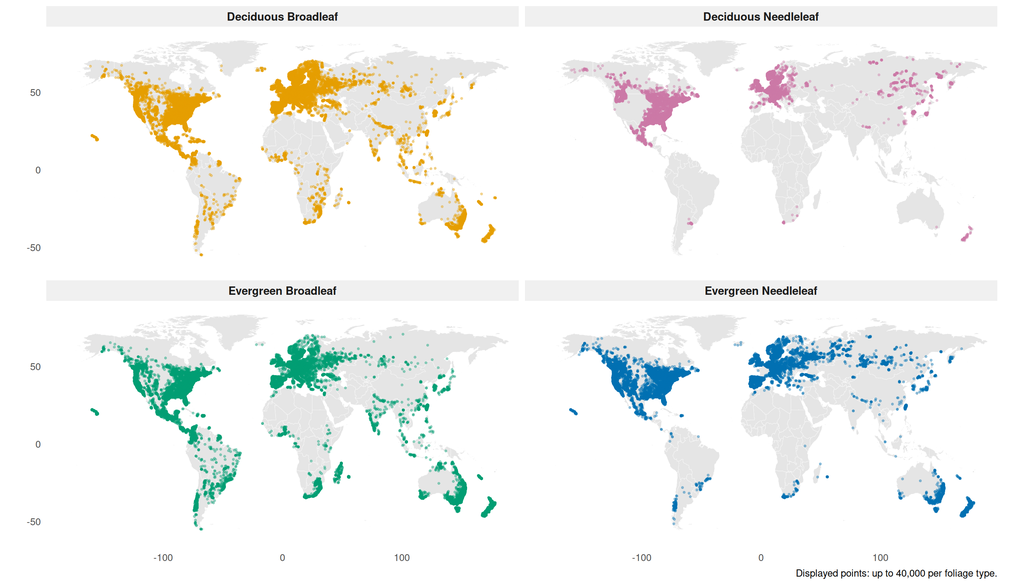

Figure 6: Geographical distribution by type of foliage

```r
palette_level0 <- c(
  "Deciduous Broadleaf"  = "#E69F00",
  "Evergreen Broadleaf"  = "#009E73",
  "Evergreen Needleleaf" = "#0072B2",
  "Deciduous Needleleaf" = "#CC79A7"
)


ggplot() +

  geom_polygon(
    data = world_map,
    aes(x = long, y = lat, group = group),
    fill = "grey90", colour = "white", linewidth = 0.1
  ) +

  geom_point(
    data = df_world_map_sample_by_level0,
    aes(x = longitude, y = latitude, colour = level0),
    alpha = 0.35, size = 0.6
  ) +

  scale_colour_manual(values = palette_level0, guide = "none") +

  facet_wrap(~ level0, ncol = 2) +      # two categories per row

  coord_fixed(1.3, xlim = c(-180, 180), ylim = c(-60, 85)) +

  plot_labs(
    x = NULL, y = NULL,
    caption = paste("Displayed points: up to", format_number(world_map_sample_n), "per foliage type.")
  ) +

  theme_minimal(base_size = 12) +

  theme(
    panel.grid  = element_blank(),
    strip.text  = element_text(face = "bold", size = 11),
    strip.background = element_rect(fill = "grey94", colour = NA)
  )
```

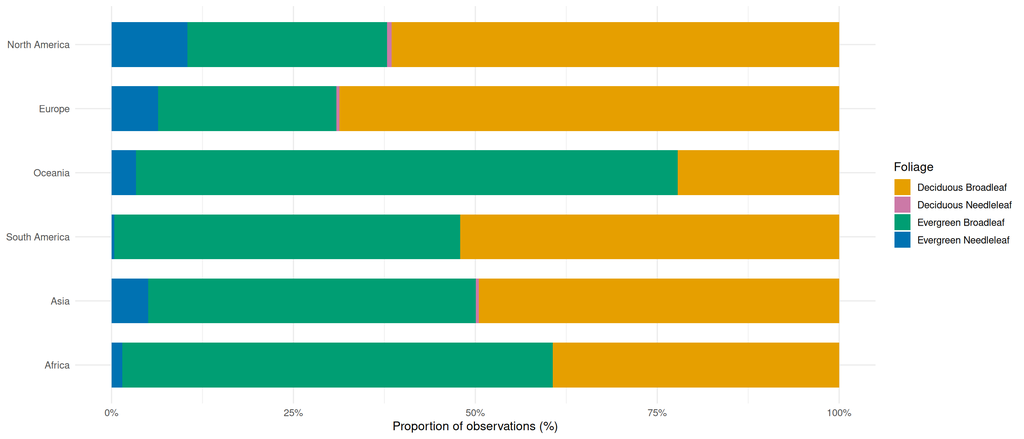

Figure 7: Geographical distribution by type of foliage

```r
df_level0 <- df %>%
  count(continent, level0, name = "n") %>%
  group_by(continent) %>%
  mutate(pct = n / sum(n) * 100) %>%    # proportion for fair comparison across continents
  ungroup() %>%
  mutate(continent = reorder(continent, n, sum))  # sort by total


ggplot(df_level0, aes(x = continent, y = pct, fill = level0)) +

  geom_col(width = 0.7) +

  scale_fill_manual(values = palette_level0, name = "Foliage") +

  scale_y_continuous(labels = scales::label_percent(scale = 1)) +

  coord_flip() +

  plot_labs(
    x = NULL, y = "Proportion of observations (%)"
  ) +

  theme_minimal(base_size = 12) +

  theme(legend.position = "right")
```

Figure 7 quantifies the relative composition of foliage types for each continent, independent of its overall sampling volume, and a clear contrast emerges between temperate and tropical/subtropical continents. North America and Europe share a similar profile, dominated by Deciduous Broadleaf (around 60–70% of observations), followed by Evergreen Broadleaf (roughly 25–30%), with Evergreen Needleleaf making up a smaller but still notable share (around 10%) not found at comparable levels on any other continent, consistent with the boreal/temperate conifer forests characteristic of these regions. Oceania and Africa, by contrast, are dominated by Evergreen Broadleaf, which accounts for the majority of observations in both (over 75% in Oceania, around 60% in Africa), with Deciduous Broadleaf as a smaller secondary category. South America and Asia present an intermediate profile, with Evergreen Broadleaf and Deciduous Broadleaf nearly evenly split at close to 50% each, suggesting these continents span a broader mix of climatic zones rather than being dominated by a single climate regime. Across all four, Evergreen Needleleaf drops to a marginal share compared to North America and Europe, and Deciduous Needleleaf is nearly absent except for a very thin presence in North America, Europe, and Asia, consistent with the restricted geographical range already observed in Figure 6. This distinction by continent, however, remains an approximation, since large countries such as the United States or China span multiple climatic zones.

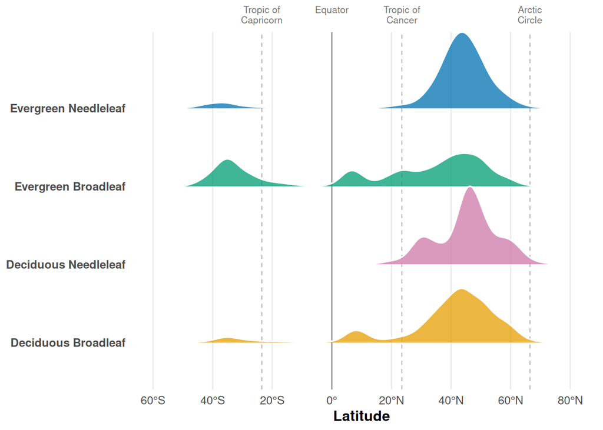

Figure 8: Distribution of foliage types by latitude

```r
# Ridge plot
ggplot(df, aes(x = latitude, y = level0, fill = level0)) +

  # Climate reference lines (drawn before the curves so they appear underneath)
  geom_vline(xintercept = 0,    colour = "grey60", linewidth = 0.5, linetype = "solid") +
  geom_vline(xintercept = 23.5, colour = "grey70", linewidth = 0.4, linetype = "dashed") +
  geom_vline(xintercept = -23.5,colour = "grey70", linewidth = 0.4, linetype = "dashed") +
  geom_vline(xintercept = 66.5, colour = "grey70", linewidth = 0.4, linetype = "dashed") +

  # Density curves with transparency gradient (gradient under the curve)
  geom_density_ridges(
    aes(fill = level0),
    alpha       = 0.75,
    scale       = 1.0,         # overlap between curves (1 = no overlap)
    rel_min_height = 0.005,    # trims very low-density tails
    bandwidth   = 3,           # smoothing in degrees of latitude
    colour      = "white",
    linewidth   = 0.6
  ) +

  scale_fill_manual(values = palette_level0, guide = "none") +

  # Headroom so the tallest curve is not clipped at the panel top.
  scale_y_discrete(expand = expansion(add = c(0.6, 0.8))) +

  # Climate zones are labelled on a top axis rather than inside the panel,
  # where rotated text would run into the curves.
  scale_x_continuous(
    breaks = seq(-60, 80, by = 20),
    labels = function(x) ifelse(x == 0, "0°", paste0(abs(x), ifelse(x > 0, "°N", "°S"))),
    sec.axis = dup_axis(
      breaks = c(-23.5, 0, 23.5, 66.5),
      labels = c("Tropic of\nCapricorn", "Equator", "Tropic of\nCancer", "Arctic\nCircle"),
      name = NULL
    )
  ) +

  coord_cartesian(xlim = c(-60, 80)) +

  plot_labs(
    x        = "Latitude",
    y        = NULL
  ) +

  theme_gtree() +

  theme(
    panel.grid.major.y = element_blank(),
    axis.text.y        = element_text(face = "bold"),
    axis.text.x.top    = element_text(size = 8, colour = "grey45", lineheight = 0.9)
  )
```

Figure 8 refines the patterns suggested by the previous map and bar chart. Evergreen Needleleaf (blue) shows a sharp peak around 45–50°N, with only a small secondary bump around 30–40°S. Deciduous Needleleaf (pink) is similarly concentrated at high northern latitudes, with a pronounced peak around 45–55°N and little recorded presence in the Southern Hemisphere. Deciduous Broadleaf (orange) has a large peak around 45–50°N, while Evergreen Broadleaf (green) is more widely distributed and has a more substantial tropical presence. Unlike the continent-level chart, the ridge plot exposes the continuous latitudinal shape of each category. These patterns are consistent with an association between foliage strategy and climate, but the plot alone cannot establish latitude as the primary driver because observation effort and other environmental variables are not controlled.

## 7.4 Taxonomic richness by continent

How much taxonomic diversity does each continent actually contain? Counting distinct species or genera per continent cannot answer this directly, because of the sampling imbalance identified above: a continent with more observations is mechanically more likely to have recorded more distinct taxa, even if its underlying biodiversity is not higher. Comparing raw taxonomic counts between continents therefore risks conflating genuine biodiversity differences with differences in sampling effort alone.

Table 2 and Figure 9 report the raw number of distinct taxa per continent, which at this stage remains directly influenced by each continent’s sampling volume (Figure 4). Figure 10 addresses that limitation through rarefaction curves, which estimate the expected number of unique species as a function of sample size, allowing continents to be compared on an equal footing regardless of how many observations were collected for each.

```r
tableau_taxa <- df %>%
  filter(!is.na(continent)) %>%
  group_by(continent) %>%
  summarise(
    Foliage = n_distinct(level0),
    Families = n_distinct(level1_family),
    Genus   = n_distinct(level2_genus),
    Species  = n_distinct(level3_species),
    Complete_taxa = n_distinct(paste(
      level1_family,
      level2_genus,
      level3_species,
      sep = "_"
    )),
    .groups = "drop"
  )


kable(tableau_taxa)
```

| continent | Foliage | Families | Genus | Species | Complete_taxa |
| --- | --- | --- | --- | --- | --- |
| Africa | 4 | 168 | 972 | 3723 | 3723 |
| Asia | 4 | 179 | 951 | 3749 | 3749 |
| Europe | 4 | 165 | 661 | 2128 | 2128 |
| North America | 4 | 202 | 1218 | 6484 | 6484 |
| Oceania | 4 | 174 | 876 | 4833 | 4833 |
| South America | 4 | 185 | 1104 | 4977 | 4977 |

Table 2: Table of the taxonomic richness by continent

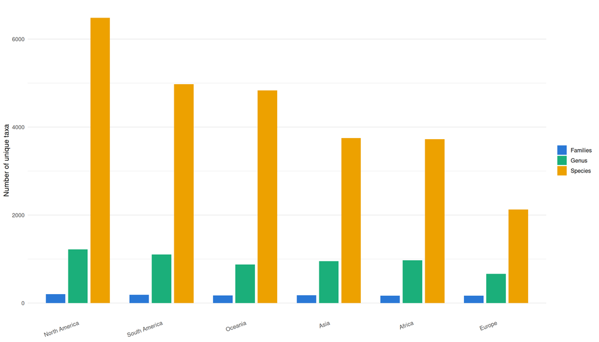

Figure 9: Taxonomic richness by continent (raw values)

```r
richness <- df %>%
  group_by(continent) %>%
  summarise(
    n_families      = n_distinct(level1_family),
    n_genera        = n_distinct(level2_genus),
    n_species       = n_distinct(level3_species),
    n_observations  = n()
  ) %>%
  mutate(
    families_100obs = round(n_families / n_observations * 100, 1),
    genera_100obs   = round(n_genera   / n_observations * 100, 1),
    species_100obs  = round(n_species  / n_observations * 100, 1)
  )

richness_long_raw <- richness %>%
  select(continent, n_families, n_genera, n_species) %>%
  pivot_longer(cols = -continent, names_to = "taxon", values_to = "value") %>%
  mutate(taxon = recode(taxon,
                        n_families = "Families",
                        n_genera   = "Genus",
                        n_species  = "Species"
  ))

# Taxon order and palette consistent with the previous chart
taxon_levels <- c("Families", "Genus", "Species")
palette_taxa <- c("Families" = "#2a78d6", "Genus" = "#1baf7a", "Species" = "#eda100")

richness_long_raw <- richness_long_raw %>%
  filter(!is.na(continent))
richness_long_raw$taxon  <- factor(richness_long_raw$taxon, levels = taxon_levels)


ggplot(richness_long_raw,
                aes(x = reorder(continent, -value), y = value, fill = taxon)) +

  geom_col(position = position_dodge(width = 0.8), width = 0.7) +

  scale_fill_manual(values = palette_taxa) +

  plot_labs(
    x = NULL, y = "Number of unique taxa",
    fill = NULL
  ) +

  theme_minimal(base_size = 12) +

  theme(
    axis.text.x = element_text(angle = 20, hjust = 1),
    panel.grid.major.x = element_blank(),
    legend.position = "right"
  )
```

This pattern suggests that raw taxonomic richness, as shown here, is not simply proportional to sampling volume, but it does not yet establish whether these differences reflect genuine biodiversity patterns or are still partly shaped by uneven sampling effort within each continent.

**Methodological note:** The `vegan::rarefy()` function calculates the expected number of recorded species in a random sample of *n* observations, drawn without replacement from each continent’s species-abundance counts. It evaluates this expectation analytically rather than performing repeated random simulations. Calculating the expectation across increasing sample sizes produces one rarefaction curve per continent. This standardises the number of observations being compared, but it does not correct for geographic coverage, source composition, detectability, or other differences in sampling design.

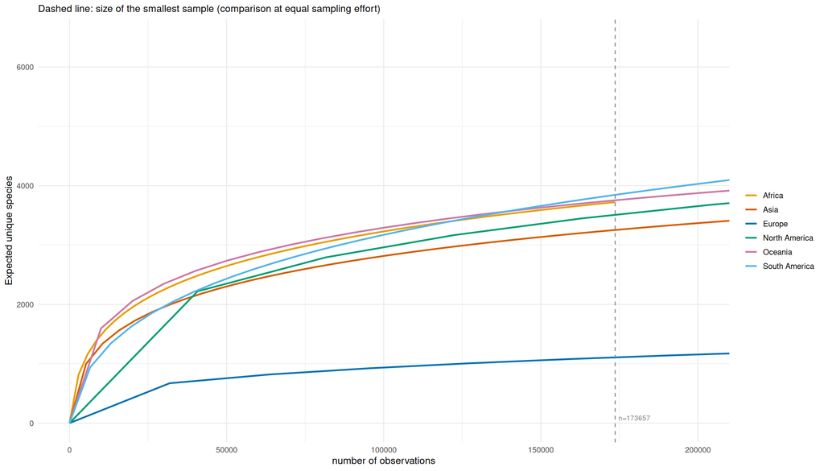

Figure 10: Rarefaction curves by continent

```r
comm_matrix <- df %>%
  st_drop_geometry() %>%
  count(continent, level3_species) %>%
  pivot_wider(names_from = level3_species, values_from = n, values_fill = 0) %>% # reshape into a "continent × species" matrix
  column_to_rownames("continent") %>%
  as.matrix()

# Total observations per continent; take the smallest for rarefaction target
min_n <- min(rowSums(comm_matrix))

# Iterate over each continent
rare_df <- purrr::map_dfr(rownames(comm_matrix), function(cont) {
  abund <- comm_matrix[cont, ] # extract the row for this continent
  N <- sum(abund) # total observations for the continent
  ns <- unique(c(seq(1, N, by = max(1, N %/% 60)), N)) # sequence of sample sizes
  S <- rarefy(matrix(abund, nrow = 1), sample = ns) # expected species count when randomly drawing n observations
  tibble(continent = cont, n = ns, S = as.numeric(S))
})

rm(comm_matrix)

ggplot(rare_df, aes(x = n, y = S, color = continent)) +

  geom_line(linewidth = 1) +

  geom_vline(xintercept = min_n, linetype = "dashed", color = "grey50") +

  annotate("text", x = min_n, y = 0,
           label = paste0("n=", min_n),
           vjust = -0.5, hjust = -0.1, size = 3, color = "grey50") +

  scale_colour_manual(values = continent_colors) +

  plot_labs(
    subtitle = "Dashed line: size of the smallest sample (comparison at equal sampling effort)",
    x = "number of observations",
    y = "Expected unique species",
    color = NULL
  ) +

  coord_cartesian(xlim = c(0, 200000)) +

  theme_minimal(base_size = 12)
```

Europe’s rarefaction curve remains below the other continents across the range shown. This indicates lower recorded richness even at equal observation counts. The difference may be consistent with ecological patterns, but it may also reflect source composition, geographic concentration, detectability, or other sampling differences that rarefaction does not remove.

Finally, Africa, Oceania, and South America remain fairly closely clustered across the observed range, suggesting comparable recorded richness after standardising observation count. This adjustment addresses sample size rather than all forms of sampling bias.

## 7.5 Changes in the distribution over time

The previous subsections treated the data as a static snapshot, without considering the recorded year. Given the strong reliance on citizen-science platforms such as iNaturalist, the number and coverage of dated observations are unlikely to be constant across the period. The figures below do not show when records were ingested into GlobalGeoTree.

Figure 11 tracks observations dated to each year alongside the number of distinct countries represented, and Figure 12 breaks that trend down by continent. Figure 13 then maps sampled observations over successive two-year periods, showing whether the spatial imbalances seen above are a stable feature of the dataset or are narrowing as it grows.

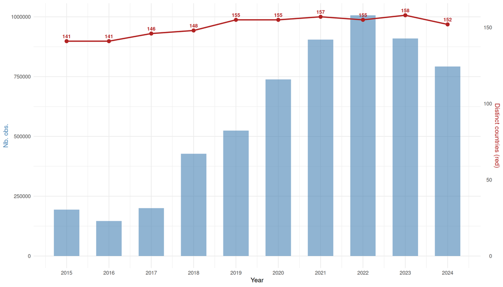

Figure 11: Observation volume and represented countries by observation year

```r
summary_year <- df %>%
  group_by(year) %>%
  summarise(
    n_obs      = n(),
    n_countries     = n_distinct(country_code),
    .groups    = "drop"
  )

coeff <- max(summary_year$n_obs) / max(summary_year$n_countries)


ggplot(summary_year, aes(x = year)) +

  # Bars for observation volume
  geom_col(aes(y = n_obs), fill = "steelblue", alpha = 0.6, width = 0.6) +

  # Line for number of distinct countries (secondary axis)
  geom_line(aes(y = n_countries * coeff), colour = "firebrick", linewidth = 1.2) +

  geom_point(aes(y = n_countries * coeff), colour = "firebrick", size = 3) +

  # Direct annotations on key data points
  geom_text(
    aes(y = n_countries * coeff, label = n_countries),
    vjust = -0.8, colour = "firebrick", size = 3.5, fontface = "bold"
  ) +

  scale_x_continuous(breaks = 2015:2024) +

  scale_y_continuous(
    name = "Nb. obs.",
    sec.axis = sec_axis(~ . / coeff, name = "Distinct countries (red)")
  ) +

  plot_labs(
    x        = "Year"
  ) +

  theme_minimal(base_size = 13) +

  theme(
    axis.title.y.right = element_text(colour = "firebrick"),
    axis.title.y.left  = element_text(colour = "steelblue")
  )
```

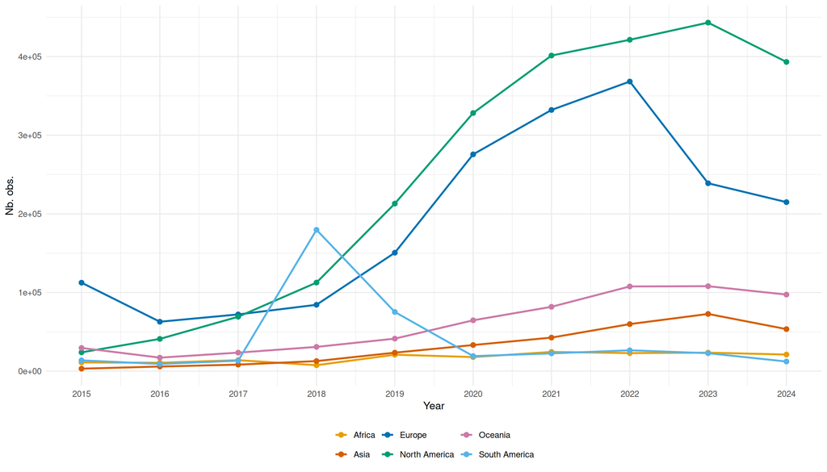

Figure 12: Observation volume by continent and observation year

```r
summary_continent <- df %>%
  count(year, continent, name = "n")


ggplot(summary_continent, aes(x = year, y = n, colour = continent)) +

  geom_line(linewidth = 1.1) +

  geom_point(size = 2.5) +

  scale_colour_manual(values = continent_colors, name = NULL) +

  scale_x_continuous(breaks = 2015:2024) +

  plot_labs(
    x = "Year", y = "Nb. obs."
  ) +

  theme_minimal(base_size = 13) +

  theme(legend.position = "bottom")
```

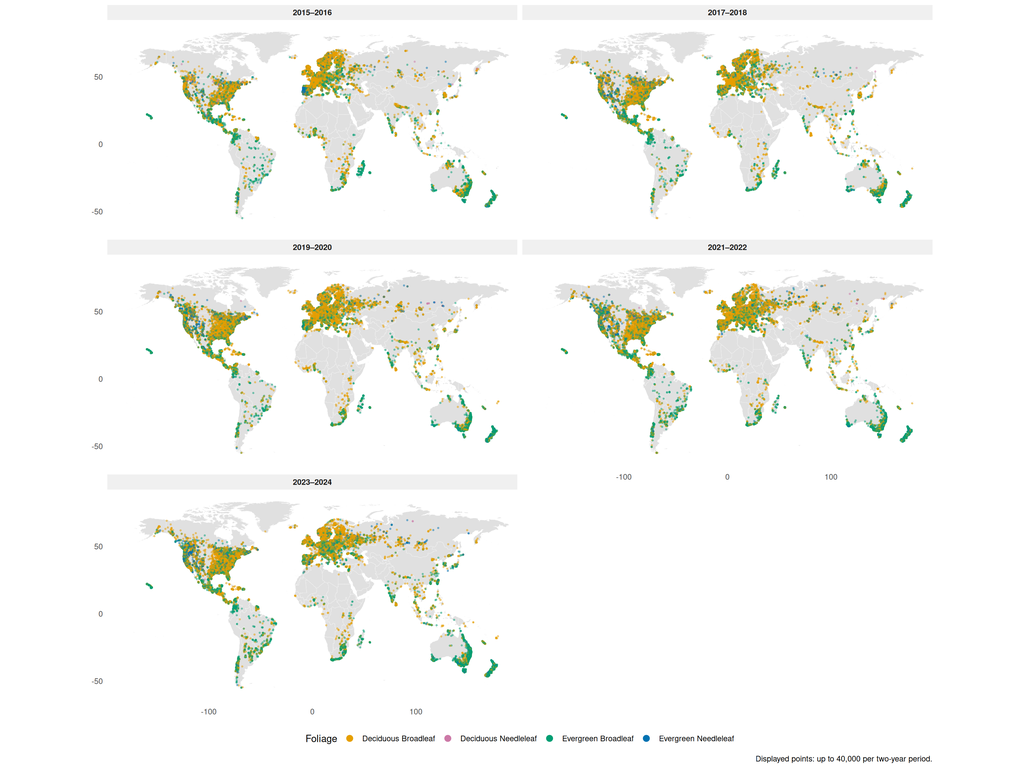

Figure 13: Geographical scope of data collection by period (5 two-year periods)

```r
df_periode <- df_world_map_sample_by_period


ggplot() +

  geom_polygon(
    data = world_map,
    aes(x = long, y = lat, group = group),
    fill = "grey88", colour = "white", linewidth = 0.08
  ) +

  geom_point(
    data = df_periode,
    aes(x = longitude, y = latitude, colour = level0),
    alpha = 0.4, size = 0.5
  ) +

  scale_colour_manual(values = palette_level0, name = "Foliage") +

  facet_wrap(~ periode, ncol = 2) +

  coord_fixed(1.3, xlim = c(-180, 180), ylim = c(-60, 85)) +

  plot_labs(
    x = NULL, y = NULL,
    caption = paste("Displayed points: up to", format_number(world_map_sample_n), "per two-year period.")
  ) +

  theme_minimal(base_size = 11) +

  theme(
    panel.grid       = element_blank(),
    legend.position  = "bottom",
    strip.text       = element_text(face = "bold"),
    strip.background = element_rect(fill = "grey94", colour = NA)
  ) +

  guides(colour = guide_legend(
    override.aes = list(alpha = 1, size = 3)   # makes the legend readable despite low alpha
  ))
```

Figure 13 confirms the trends identified in the two previous figures spatially, while adding a further dimension: foliage type. Across all five period panels, the geographical footprint of the dataset remains remarkably stable — the same broad regions (North America, Europe, coastal South America, parts of Africa and Southeast Asia/Oceania) are already represented as early as 2015–2016, with no major new region appearing later. This is consistent with the near-total country coverage observed in Figure 11: geographical breadth was established early, and subsequent growth in volume (Figure 12) has taken the form of densification within already-sampled areas rather than expansion into new ones. Point coverage becomes progressively denser and more continuous over North America and Europe, particularly for Deciduous Broadleaf (orange) and Evergreen Broadleaf (green), while central Africa, the Amazon interior, and Central Asia remain visibly sparse throughout all five periods.

Overall, this final figure shows that the geographic imbalance is visible throughout the full range of observation years. This is consistent with a persistent structural bias in the dated records, while not describing when the contributing records were actually ingested into GlobalGeoTree.

# Part II: Germany and Berlin Analysis

*— Nataliia*

Part II examines tree observations within Germany.

```r
# Filter to Germany and ensure valid coordinates for mapping
germany <- df |>
  filter(country_code == "DE",
         !is.na(latitude), !is.na(longitude),
         between(latitude, -90, 90), between(longitude, -180, 180))

germany_points <- sf::st_as_sf(germany, coords = c("longitude", "latitude"), crs = 4326, remove = FALSE)
```

```r
de_input_summary <- tibble::tibble(
  item = c("Total observations (all countries)", "Germany observations used in Part II"),
  value = c(format_number(nrow(df)), format_number(nrow(germany)))
)
nice_table(de_input_summary, "Germany data check")
```

Germany data check

| item | value |
| --- | --- |
| Total observations (all countries) | 5,843,499 |
| Germany observations used in Part II | 203,728 |

# 8 Germany: Species and Common-Name Lookup

To make charts easier to read, English common names are shown next to Latin names wherever possible. The GlobalGeoTree dataset contains `species_key`, a unique GBIF identifier for each species. This key is used to query the GBIF vernacular-names API once and cache the result in `data/external/species_common_names.csv`. On every subsequent render, the report reads from that file.

```r
german_species_for_names <- germany |>
  filter(!is.na(level3_species), level3_species != "") |>
  group_by(level3_species, species_key) |>
  summarise(de_observations = n(), .groups = "drop") |>
  arrange(desc(de_observations))

species_count_summary <- tibble::tibble(
  metric = c("Unique species in German observations", "Species with a valid GBIF species key"),
  value = c(
    format_number(n_distinct(german_species_for_names$level3_species)),
    format_number(sum(!is.na(german_species_for_names$species_key) &
                        german_species_for_names$species_key != ""))
  )
)
nice_table(species_count_summary, "German species overview")
```

German species overview

| metric | value |
| --- | --- |
| Unique species in German observations | 464 |
| Species with a valid GBIF species key | 464 |

```r
species_names_path <- file.path(external_data_path, "species_common_names.csv")

if (!file.exists(species_names_path)) {
  if (!requireNamespace("jsonlite", quietly = TRUE)) {
    stop("Install jsonlite to fetch species names: install.packages('jsonlite')")
  }

  species_with_key <- german_species_for_names |>
    filter(!is.na(species_key), species_key != "")

  # Fetches the first English common name for a species from the GBIF API.
  # A small delay (0.08s) is added between requests to avoid overloading the API.
  fetch_en_name <- function(key) {
    url <- paste0("https://api.gbif.org/v1/species/", key, "/vernacularNames?limit=30")
    resp <- tryCatch(jsonlite::fromJSON(url, simplifyDataFrame = TRUE), error = function(e) NULL)
    Sys.sleep(0.08)
    if (is.null(resp) || !is.data.frame(resp$results) || nrow(resp$results) == 0) return(NA_character_)
    en <- resp$results$vernacularName[resp$results$language == "eng"]
    if (length(en) == 0) return(NA_character_)
    en[1]
  }

  species_with_key$common_name_en <- vapply(species_with_key$species_key, fetch_en_name, character(1))
  write.csv(species_with_key, species_names_path, row.names = FALSE)
}

species_names_raw <- read.csv(species_names_path, stringsAsFactors = FALSE) |> tibble::as_tibble()
species_common_names <- species_names_raw |>
  select(level3_species, common_name_en) |>
  filter(!is.na(common_name_en), common_name_en != "")

fetch_names_status <- tibble::tibble(
  metric = c("Species queried from GBIF", "Species with an English common name"),
  value = c(format_number(nrow(species_names_raw)), format_number(nrow(species_common_names)))
)
nice_table(fetch_names_status, "GBIF common names lookup result")
```

GBIF common names lookup result

| metric | value |
| --- | --- |
| Species queried from GBIF | 464 |
| Species with an English common name | 421 |

Species without an English name in GBIF are shown with their Latin name only in charts.

# 9 Germany: National Patterns

This section examines how tree observations are distributed across Germany as a whole: spatial concentration, temporal trends, source structure, and federal state-level variation.

## 9.1 Pre-Processing

Polygons for the federal states (Bundesländer) are needed to draw state boundaries on Germany maps and to assign observations to states. The code first looks for a local GeoJSON file; if it is not found, the public GISCO NUTS1 file is downloaded.

```r
bundeslaender_result <- read_geojson_local_or_url(
  bundeslaender_local_path, gisco_nuts1_url, "federal state / NUTS1"
)
bundeslaender <- bundeslaender_result$data

if (!is.null(bundeslaender)) {
  if ("cntr_code" %in% names(bundeslaender)) {
    bundeslaender <- bundeslaender |> filter(as.character(cntr_code) == "DE")
  }
  if ("levl_code" %in% names(bundeslaender)) {
    bundeslaender <- bundeslaender |> filter(as.character(levl_code) == "1")
  }
  name_col <- intersect(c("name_latn", "nuts_name", "name", "nuts_id"), names(bundeslaender))[1]
  if (is.na(name_col)) {
    bundeslaender$bundesland <- paste("Federal state", seq_len(nrow(bundeslaender)))
  } else {
    bundeslaender$bundesland <- as.character(bundeslaender[[name_col]])
  }
  bundeslaender <- bundeslaender |>
    select(bundesland, geometry) |>
    filter(!is.na(bundesland), bundesland != "")
}

has_bundeslaender <- !is.null(bundeslaender) && nrow(bundeslaender) > 0
bundeslaender_plot <- simplify_for_plot(bundeslaender, tolerance = 0.01)

bundeslaender_status <- tibble::tibble(
  item = c("Boundary status", "Number of federal state polygons"),
  value = c(bundeslaender_result$note, ifelse(has_bundeslaender, format_number(nrow(bundeslaender)), "0"))
)
nice_table(bundeslaender_status, "Federal state boundary check")
```

Federal state boundary check

| item | value |
| --- | --- |
| Boundary status | Loaded federal state / NUTS1 boundaries from data/external/germany_nuts1_2021.geojson |
| Number of federal state polygons | 16 |

```r
nuts3_result <- read_geojson_local_or_url(nuts3_local_path, gisco_nuts3_url, "NUTS3")
nuts3 <- nuts3_result$data
```

## 9.2 Distribution of observations in Germany

- *Where are observations spatially concentrated across Germany?*

Two complementary views are shown below. Figure 14 is a smooth filled density surface, which highlights where observations concentrate into hotspots; Figure 15 plots the individual observation points the surface is derived from, revealing the raw recording locations behind those contours.

```r
germany_points_for_maps <- sample_up_to(germany, max_germany_overview_points)
germany_boundary_for_maps <- if (has_bundeslaender) dplyr::bind_rows(bundeslaender_plot) else NULL
```

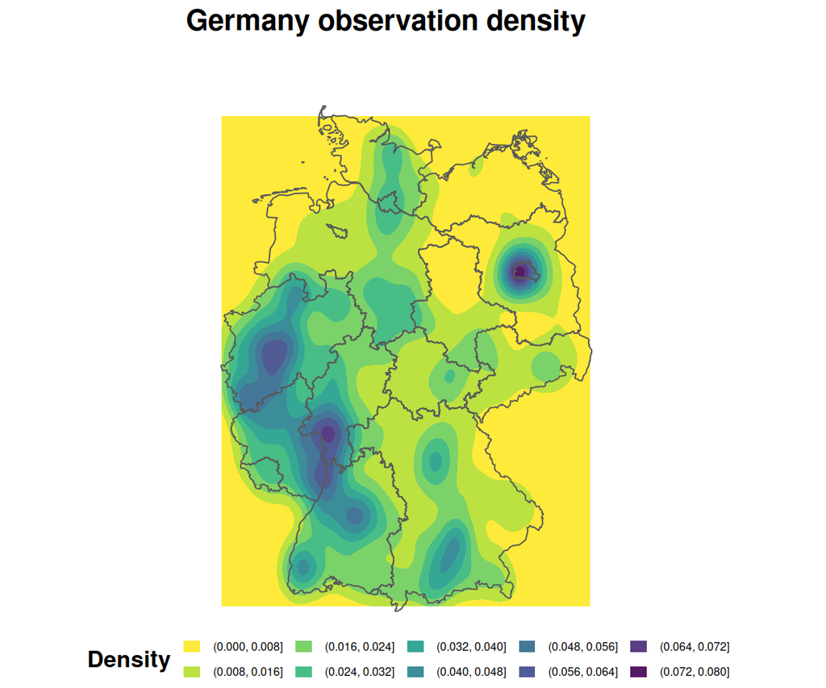

Figure 14: Smoothed density of Germany observations

```r
if (nrow(germany_points_for_maps) < 3) {
  empty_plot("Not enough Germany observations were available for the distribution maps.")
} else {
  plot_filled_density_map(
    points_data = germany_points_for_maps,
    boundary_data = germany_boundary_for_maps,
    title = "Germany observation density",
    subtitle = NULL,
    caption = NULL,
    xlim = germany_xlim, ylim = germany_ylim, bins = 10, alpha = 0.90
  )
}
```

Darker areas show where more observations were recorded. **This is the central caveat for the whole of Part II: every map, chart and count that follows measures recording intensity, not tree abundance.** A location can appear dense because observers are active there, because a platform has strong coverage, or simply because access is easier. Nothing in this dataset distinguishes a place with many trees from a place with many observers, so the two must not be read as the same thing.

Recording is highest in western and southwestern Germany, with a separate strong hotspot around Berlin. Large parts of eastern and northeastern Germany have much lower density.

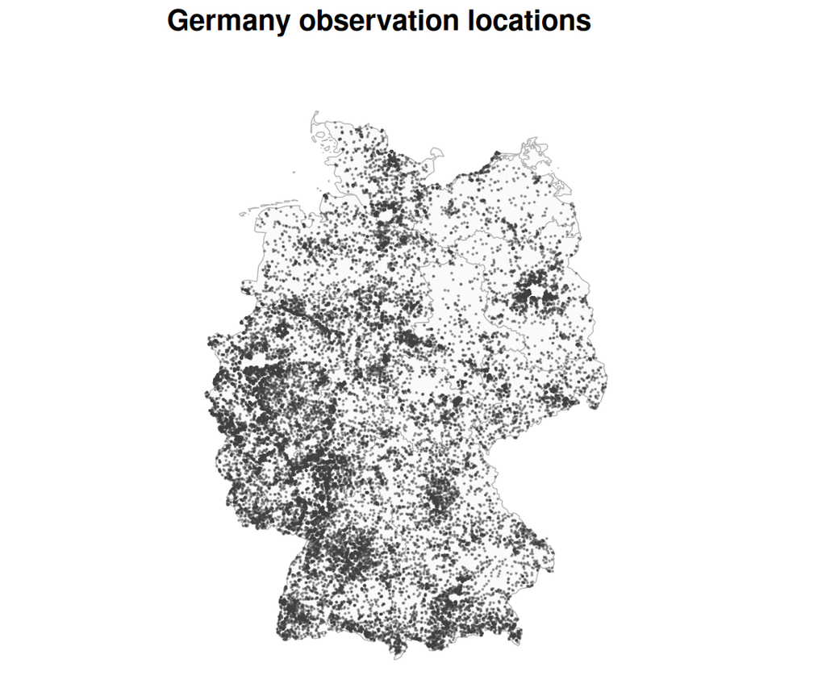

Figure 15: Locations of Germany observations

```r
if (nrow(germany_points_for_maps) < 3) {
  empty_plot("Not enough Germany observations were available for the distribution maps.")
} else {
  p <- ggplot()
  if (!is.null(germany_boundary_for_maps)) {
    p <- p + geom_sf(data = germany_boundary_for_maps, fill = "gray98", color = "gray70", linewidth = 0.25)
  }
  p +
    geom_point(data = germany_points_for_maps, aes(x = longitude, y = latitude),
               alpha = 0.4, size = 0.02, color = "gray25") +
    coord_sf(xlim = germany_xlim, ylim = germany_ylim, expand = FALSE) +
    plot_labs(title = "Germany observation locations", caption = NULL) +
    theme_map_gtree()
}
```

Figure 15 confirms the same pattern: observations cluster strongly in the west and south, while the east is more sparsely covered outside Berlin.

## 9.3 Observations by year

- *How has recording activity changed over time in Germany?*

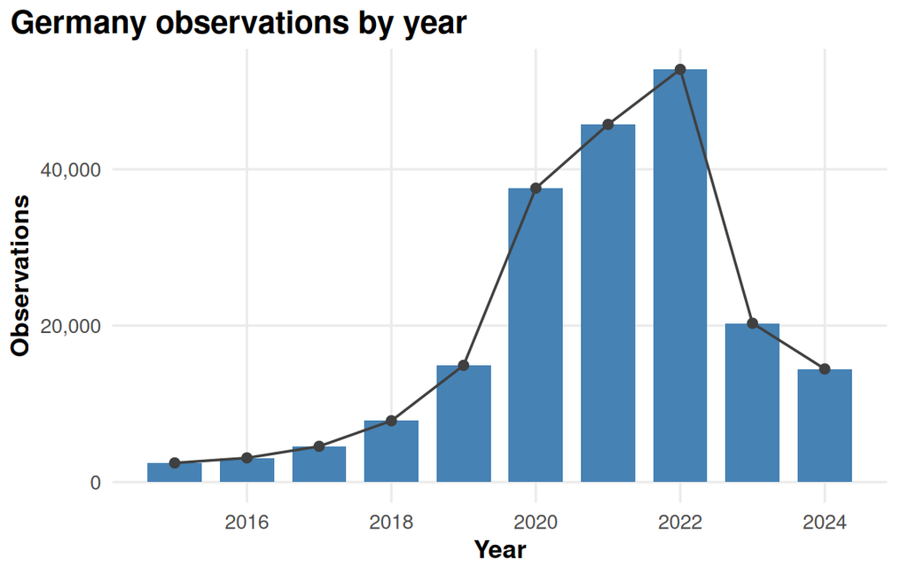

Figure 16: Germany observations by year

```r
year_counts <- germany |>
  filter(!is.na(year), year >= 1900, year <= as.integer(format(Sys.Date(), "%Y"))) |>
  count(year, name = "observations") |>
  arrange(year)

if (nrow(year_counts) == 0) {
  empty_plot("No usable year values were found in the Germany rows.")
} else {
  ggplot(year_counts, aes(x = year, y = observations)) +
    geom_col(width = 0.75, fill = "steelblue") +
    geom_line(linewidth = 0.6, color = "gray25") +
    geom_point(size = 1.8, color = "gray25") +
    scale_x_continuous(breaks = scales::pretty_breaks()) +
    scale_y_continuous(labels = scales::comma_format()) +
    plot_labs(title = "Germany observations by year", x = "Year", y = "Observations") +
    theme_gtree()
}
```

Recording grows steeply through the second half of the period, which is common in citizen-science datasets as more users join the platforms. Volume peaks in **2022** and then falls over the final two years.

## 9.4 Source footprints across Germany

- *Which platforms contribute the most records in Germany, and do they cover the country differently?*

Figure 16 shows *when* Germany observations were recorded; this subsection examines *who* recorded them. Each panel of Figure 17 shows where one source collected its records.

Note that “source” here means an individual platform, not one of the six source groups defined by `classify_source()` in Part I. Germany is dominated by so few platforms that the individual names are more informative than the groups; the five largest are shown separately and everything else is pooled into “Other sources”.

```r
source_counts_de <- germany |>
  count(source_raw, name = "observations", sort = TRUE) |>
  mutate(share = observations / sum(observations), source_short = make_source_label(source_raw))

top_sources_de <- source_counts_de |> slice_head(n = 5) |> pull(source_raw)

germany_sources <- germany |>
  mutate(
    source_display = if_else(source_raw %in% top_sources_de, make_source_label(source_raw), "Other sources"),
    source_display = stringr::str_wrap(source_display, width = 20)
  )

# Counts for the bar chart
de_source_counts <- germany_sources |>
  count(source_display, name = "observations", sort = TRUE) |>
  mutate(
    share = observations / sum(observations),
    label = paste0(format_number(observations), " (", format_percent(share), ")"),
    source_display = factor(source_display, levels = rev(source_display))
  )

source_map_data_de <- germany_sources |>
  group_by(source_display) |>
  group_modify(~ sample_up_to(.x, max_points_per_source_group)) |>
  ungroup() |>
  mutate(source_display = factor(source_display, levels = levels(de_source_counts$source_display)))
```

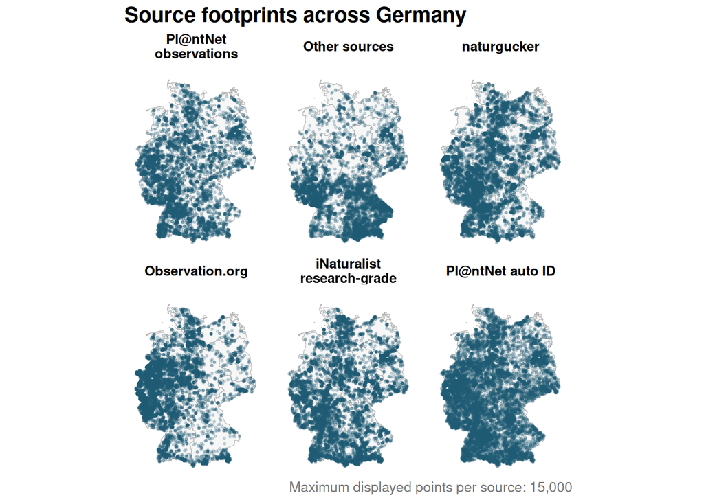

Figure 17: Source footprints in Germany

```r
p <- ggplot()
if (has_bundeslaender) {
  p <- p + geom_sf(data = bundeslaender_plot, fill = "gray97", color = "gray70", linewidth = 0.2)
}
p +
  geom_point(data = source_map_data_de, aes(x = longitude, y = latitude),
             alpha = 0.20, size = 0.45, color = "#1F5B74") +
  facet_wrap(~ source_display, ncol = 3) +
  coord_sf(xlim = germany_xlim, ylim = germany_ylim, expand = FALSE) +
  plot_labs(
    title = "Source footprints across Germany",
    caption = paste("Maximum displayed points per source:", format_number(max_points_per_source_group))
  ) +
  theme_map_gtree()
```

Figure 17 shows clear differences in where each source records observations. Observation.org and Pl@ntNet are more concentrated in western and southern Germany, while naturgucker and iNaturalist have broader national coverage. Pl@ntNet auto ID appears the most evenly spread, although the 15,000-point limit per panel means these show coverage patterns rather than total record numbers.

## 9.5 Observations by source

Figure 17 shows *where* each source records; Figure 18 shows *how many* records each source contributes.

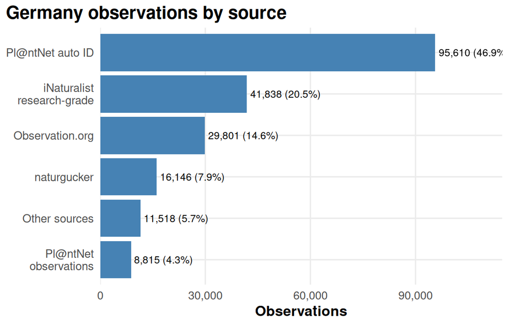

Figure 18: Germany observations by source

```r
ggplot(de_source_counts, aes(x = source_display, y = observations)) +
  geom_col(fill = "steelblue") +
  geom_text(aes(label = label), hjust = -0.05, size = 3) +
  coord_flip() +
  scale_y_continuous(labels = scales::comma_format(), expand = expansion(mult = c(0, 0.20))) +
  plot_labs(title = "Germany observations by source", subtitle = NULL, x = NULL, y = "Observations") +
  theme_gtree()
```

Pl@ntNet auto ID contributes 46.9% of all German records — almost half. iNaturalist research-grade and Observation.org add another 35.2%, so the three largest sources together account for 82.1% of the dataset. The remaining sources make much smaller contributions, meaning national patterns are shaped mainly by these three platforms.

This inverts the global picture. Part I showed that iNaturalist alone contributes 64.4% of all observations worldwide and is by some margin the largest single source. In Germany it is only the second largest, behind an automated identification pipeline. Germany is therefore not a scaled-down version of the global dataset: whichever platform happens to have market share in a given country determines what its records look like, and conclusions drawn at one geographic scale do not transfer to another.

`Pl@ntNet observations` and `Pl@ntNet auto ID` are both Pl@ntNet-derived but represent different validation routes: one is the regular shared-observation dataset, and the other contains automatically identified occurrences. They are therefore kept separate throughout this report.

## 9.6 Observations mapped to federal states

- *How are observations distributed across Germany’s sixteen federal states?*

Observations are assigned to federal states using a spatial join — each observation’s coordinates are matched to the boundary polygon it falls within.

```r
if (has_bundeslaender) {
  # Spatial join: assign each observation to the Bundesland whose polygon contains it
  germany_bundeslaender <- sf::st_join(germany_points, bundeslaender, left = FALSE, join = sf::st_within) |>
    sf::st_drop_geometry() |> tibble::as_tibble()
  germany_bundeslaender_n <- nrow(germany_bundeslaender)

  # Aggregate: count observations, species, and sources per Bundesland
  bundesland_counts <- germany_bundeslaender |>
    group_by(bundesland) |>
    summarise(observations = n(), species = n_distinct(level3_species),
              sources = n_distinct(source_raw), .groups = "drop") |>
    arrange(desc(observations))

  # Join counts back to the boundary polygons for the choropleth map
  bundesland_map <- bundeslaender |>
    left_join(bundesland_counts, by = "bundesland") |>
    mutate(observations = dplyr::coalesce(observations, 0L),
           species = dplyr::coalesce(species, 0L),
           sources = dplyr::coalesce(sources, 0L))
  bundesland_map_plot <- simplify_for_plot(bundesland_map, tolerance = 0.01)
  rm(germany_bundeslaender)
} else {
  germany_bundeslaender_n <- 0L
  bundesland_counts <- tibble::tibble()
  bundesland_map <- NULL
  bundesland_map_plot <- NULL
}

bundesland_join_check <- tibble::tibble(
  metric = c("Germany observations before join", "Matched to a federal state", "Federal states with observations"),
  value = c(format_number(nrow(germany)), format_number(germany_bundeslaender_n), format_number(nrow(bundesland_counts)))
)
nice_table(bundesland_join_check, "Federal state spatial join check")
```

Federal state spatial join check

| metric | value |
| --- | --- |
| Germany observations before join | 203,728 |
| Matched to a federal state | 203,234 |
| Federal states with observations | 16 |

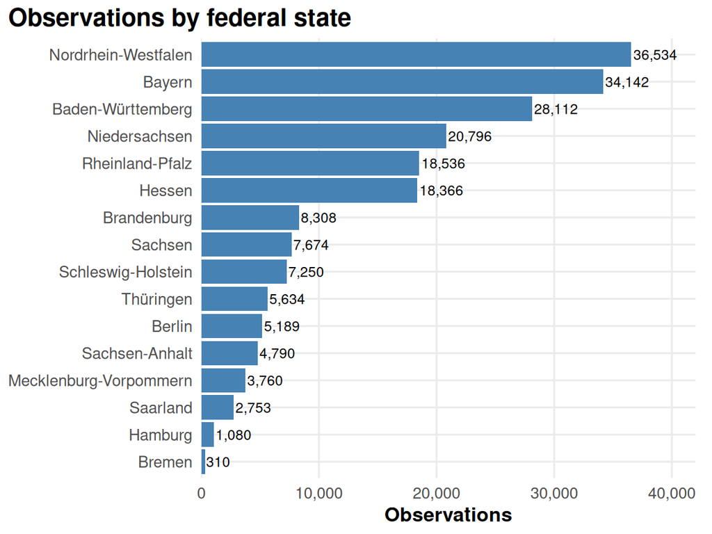

Figure 19: Germany observations by federal state

```r
if (nrow(bundesland_counts) == 0) {
  empty_plot("Federal state counts are unavailable because the boundary file was not loaded.")
} else {
  ggplot(bundesland_counts, aes(x = reorder(bundesland, observations), y = observations)) +
    geom_col(fill = "steelblue") +
    geom_text(aes(label = format_number(observations)), hjust = -0.05, size = 3) +
    coord_flip() +
    scale_y_continuous(labels = scales::comma_format(), expand = expansion(mult = c(0, 0.15))) +
    plot_labs(title = "Observations by federal state", x = NULL, y = "Observations") +
    theme_gtree()
}
```

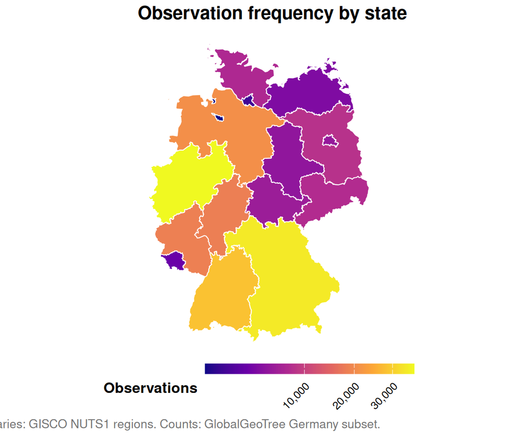

Figure 20: Observation frequency by federal state

```r
if (is.null(bundesland_map)) {
  empty_plot("Federal state map is unavailable because the boundary file was not loaded.")
} else {
  ggplot(bundesland_map_plot) +
    geom_sf(aes(fill = observations), color = "white", linewidth = 0.35) +
    scale_fill_viridis_c(option = "C", trans = "sqrt", labels = scales::comma_format(),
                         breaks = scales::breaks_pretty(n = 5),
                         guide = guide_colorbar(
                           barwidth = 12, barheight = 0.6,
                           label.theme = element_text(angle = 45, hjust = 1, size = 9)
                         )) +
    plot_labs(
      title = "Observation frequency by state",
      subtitle = NULL,
      fill = "Observations",
      caption = "Boundaries: GISCO NUTS1 regions. Counts: GlobalGeoTree Germany subset."
    ) +
    theme_map_gtree()
}
```

Figure 19 provides exact rankings, while Figure 20 shows whether high-record states cluster in one part of Germany.

Observations are concentrated in western and southern Germany. North Rhine-Westphalia has the highest count, with Bavaria, Baden-Württemberg and Lower Saxony also recording many observations. Eastern states and Saarland generally have fewer records, showing that sampling effort is uneven across Germany.

That ranking is worth a second look, because it closely follows the states’ populations rather than anything about trees: North Rhine-Westphalia, Bavaria, Baden-Württemberg and Lower Saxony are also Germany’s four most populous states, in almost that order. The counts here are raw totals, not normalised by area or population, so the chart cannot separate “more trees” from “more people who record trees” — and the population ordering suggests the second reading is the stronger one. Confirming this would need observations per capita or per square kilometre, which this report does not compute; it is noted here as a limitation on how Figure 19 should be read.

# 10 Berlin

Berlin is the city of our university, which is why it was selected as the main target for regional analysis in Germany. As a city-state, Berlin’s entire area is urban, which may produce recording patterns quite different from larger, more rural federal states. Whether that expectation holds is tested below — it does not.

## 10.1 Pre-Processing

Berlin is handled separately because a finer boundary layer than the federal states is needed for city-level analysis. The boundaries come from an open-data project and provide polygons for Berlin’s **local areas (Ortsteile)** — the small sub-units nested inside Berlin’s twelve boroughs (Bezirke). “Local area” always refers to an Ortsteil in this part of the report; the polygon count is reported in the boundary check below.

```r
berlin_result <- read_geojson_local_or_url(berlin_local_path, berlin_district_url, "Berlin local-area")
berlin_districts <- berlin_result$data

if (!is.null(berlin_districts)) {
  name_col <- intersect(c("name", "bezirk", "district", "gemeinde_name", "gen", "ortsteil"), names(berlin_districts))[1]
  if (is.na(name_col)) {
    berlin_districts$district <- paste("Area", seq_len(nrow(berlin_districts)))
  } else {
    berlin_districts$district <- as.character(berlin_districts[[name_col]])
  }
  berlin_districts <- berlin_districts |>
    select(district, geometry) |>
    filter(!is.na(district), district != "")
}

has_berlin_districts <- !is.null(berlin_districts) && nrow(berlin_districts) > 0
berlin_districts_plot <- simplify_for_plot(berlin_districts, tolerance = 0.0005)

berlin_boundary_status <- tibble::tibble(
  item = c("Berlin boundary status", "Number of Berlin polygons"),
  value = c(berlin_result$note, ifelse(has_berlin_districts, format_number(nrow(berlin_districts)), "0"))
)
nice_table(berlin_boundary_status, "Berlin boundary check")
```

Berlin boundary check

| item | value |
| --- | --- |
| Berlin boundary status | Loaded Berlin local-area boundaries from data/external/berlin_districts.geojson |
| Number of Berlin polygons | 97 |

## 10.2 Berlin observations

```r
if (has_berlin_districts) {
  district_bbox <- sf::st_bbox(berlin_districts)
  germany_points_near_berlin <- germany_points |>
    filter(longitude >= district_bbox[["xmin"]], longitude <= district_bbox[["xmax"]],
           latitude >= district_bbox[["ymin"]], latitude <= district_bbox[["ymax"]])
  berlin_joined <- sf::st_join(germany_points_near_berlin, berlin_districts, left = FALSE, join = sf::st_within)
  berlin <- berlin_joined |> sf::st_drop_geometry() |> tibble::as_tibble()
  berlin_filter_method <- "Spatial join to Berlin district/local-area polygons"
  rm(berlin_joined, germany_points_near_berlin)
} else {
  berlin <- germany |>
    filter(longitude >= berlin_bbox$lon_min, longitude <= berlin_bbox$lon_max,
           latitude >= berlin_bbox$lat_min, latitude <= berlin_bbox$lat_max) |>
    mutate(district = NA_character_)
  berlin_filter_method <- "Approximate Berlin bounding box fallback"
}

berlin_summary <- make_state_summary(berlin, "Berlin", berlin_filter_method)
nice_table(berlin_summary, "Berlin observation summary")
```

Berlin observation summary

| metric | value |
| --- | --- |
| Berlin filtering method | Spatial join to Berlin district/local-area polygons |
| Berlin observations | 5,192 |
| Berlin recorded species | 158 |
| Berlin recorded genera | 85 |
| Berlin recorded families | 43 |
| Available source values | 13 |
| Available years | 2015-2024 |

## 10.3 Berlin observation sources

- *Which data sources contribute to Berlin’s observations, and does one platform dominate?*

```r
berlin_source_counts <- make_source_counts(berlin)
# Counts feed the bar chart below; the table view was removed as it duplicated that chart.
```

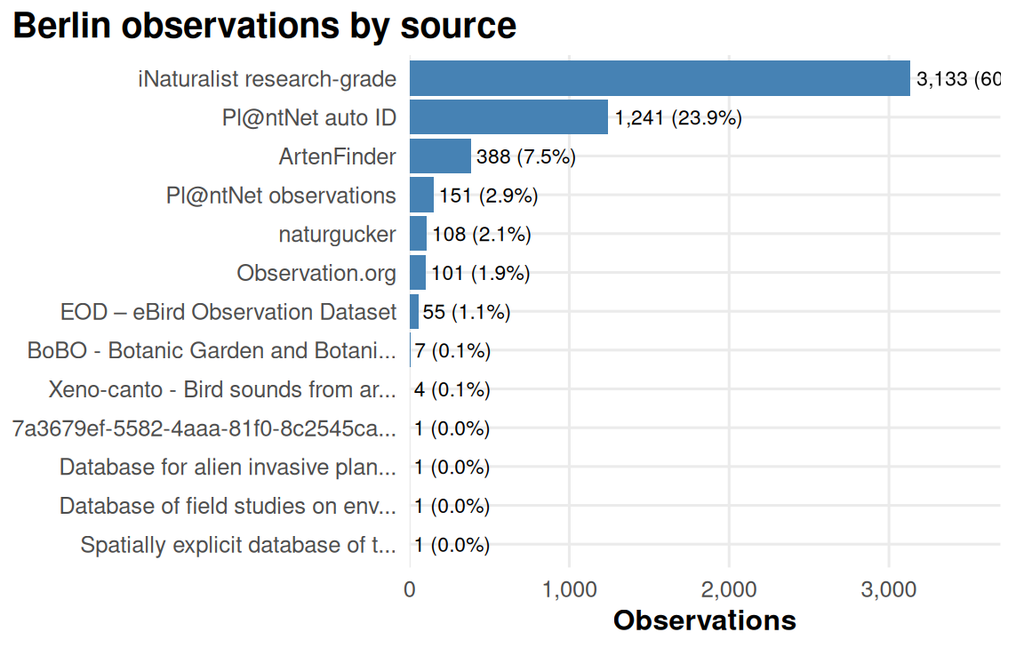

Figure 21: Berlin observations by source

```r
ggplot(berlin_source_counts, aes(x = source_short, y = observations)) +
  geom_col(fill = "steelblue") +
  geom_text(aes(label = label), hjust = -0.05, size = 3) +
  coord_flip() +
  scale_y_continuous(labels = scales::comma_format(), expand = expansion(mult = c(0, 0.18))) +
  plot_labs(title = "Berlin observations by source", x = NULL, y = "Observations") +
  theme_gtree()
```

As Figure 21 shows, Berlin’s records are strongly dominated by iNaturalist research-grade, which contributes 60.3% of observations. Pl@ntNet auto ID adds another 23.9%, while ArtenFinder contributes 7.5%. Together, these three sources provide 91.7% of the Berlin dataset.

The majority of Berlin observations come from citizen-science platforms — both global ones, such as iNaturalist and Pl@ntNet, and local ones, such as ArtenFinder and naturgucker.

The source mix has now flipped twice. iNaturalist leads globally (Part I), Pl@ntNet auto ID leads nationally in Germany (Figure 18), and Berlin reverts to iNaturalist research-grade at 60.3%. Berlin is not representative of Germany in the way that Germany is not representative of the world. Each nested scale is dominated by a different platform, so the composition of any GlobalGeoTree subset has to be checked at the scale being analysed rather than inherited from the level above.

## 10.4 Spatial distribution of Berlin observations

- *Which parts of Berlin show the highest recording density?*

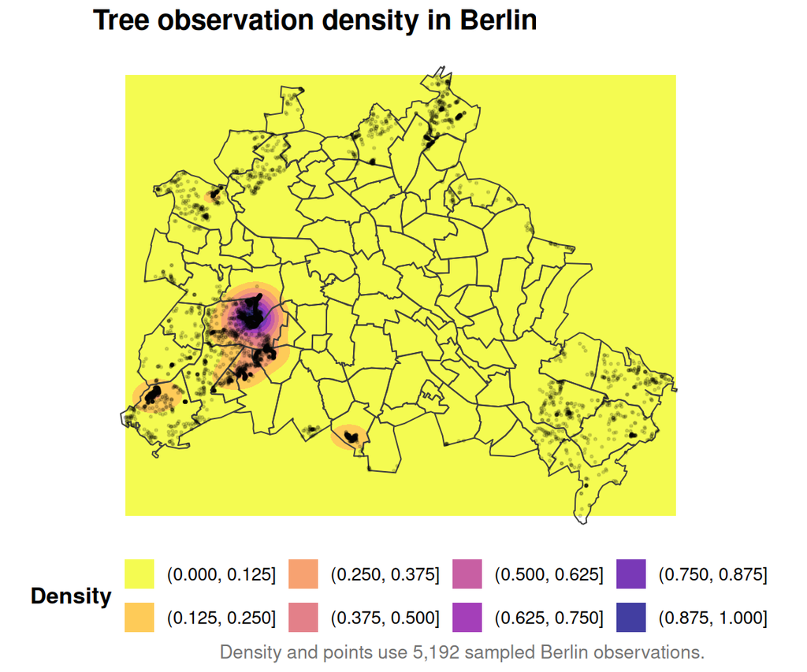

Figure 22: Tree observation density in Berlin

```r
berlin_points_for_map <- sample_up_to(berlin, max_berlin_points)

if (nrow(berlin_points_for_map) < 3) {
  empty_plot("Not enough Berlin observations were available for a density map.")
} else if (has_berlin_districts) {
  ggplot() +
    stat_density_2d_filled(data = berlin_points_for_map,
                           aes(x = longitude, y = latitude, fill = after_stat(level)),
                           contour_var = "ndensity", bins = 8, alpha = 0.78) +
    geom_sf(data = berlin_districts_plot, fill = NA, color = "gray25", linewidth = 0.35) +
    geom_point(data = berlin_points_for_map, aes(x = longitude, y = latitude), alpha = 0.14, size = 0.35) +
    coord_sf() +
    scale_fill_viridis_d(option = "C", direction = -1, name = "Density") +
    plot_labs(title = "Tree observation density in Berlin",
         caption = paste("Density and points use", format_number(nrow(berlin_points_for_map)), "sampled Berlin observations."),
         x = NULL, y = NULL) +
    theme_map_gtree()
} else {
  ggplot(berlin_points_for_map, aes(x = longitude, y = latitude)) +
    stat_density_2d_filled(contour_var = "ndensity", bins = 8, alpha = 0.8) +
    geom_point(alpha = 0.12, size = 0.35) +
    coord_fixed() +
    scale_fill_viridis_d(option = "C", direction = -1, name = "Density") +
    plot_labs(title = "Tree observation density in Berlin",
         subtitle = "Local-area borders were unavailable, so this map uses the Berlin bounding-box fallback.",
         caption = paste("Density and points use", format_number(nrow(berlin_points_for_map)), "sampled Berlin observations."),
         x = "Longitude", y = "Latitude") +
    theme_gtree()
}
```

Figure 22 highlights which parts of Berlin have the most recorded tree observations. As always in this part, high-density areas correspond to parks, green corridors, and neighbourhoods with active observers rather than to places that necessarily hold more trees.

Observations are strongly concentrated in western Berlin, with the clearest hotspot just west of the city centre, in Grunewald. Smaller clusters appear in the southwest and along the southern edge, while most central and eastern local areas have much lower recording density.

## 10.5 Berlin local areas: observations and species

- *Do the local areas with the most observations also have the most recorded species?*

```r
if ("district" %in% names(berlin) && any(!is.na(berlin$district))) {
  berlin_district_counts <- berlin |>
    filter(!is.na(district), district != "") |>
    group_by(district) |>
    summarise(observations = n(), species = n_distinct(level3_species),
              sources = n_distinct(source_raw), .groups = "drop") |>
    arrange(desc(observations))
} else {
  berlin_district_counts <- tibble::tibble()
}

# Counts feed the bar charts and choropleth below; the table view was removed as redundant.
```

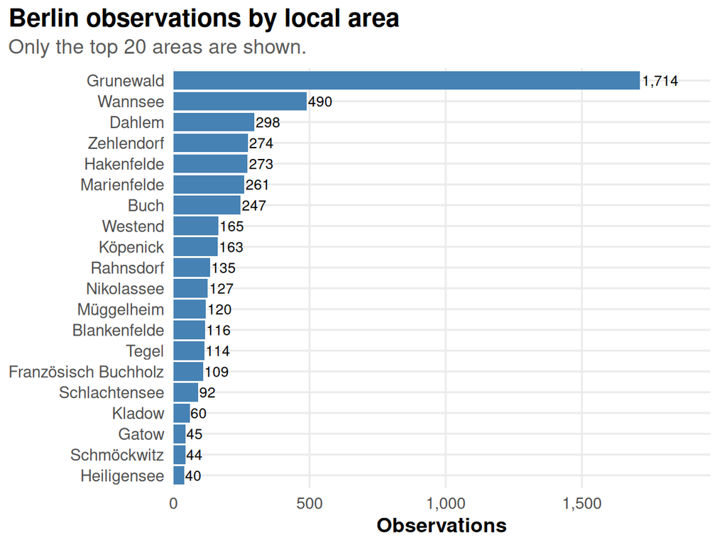

Figure 23: Berlin observations by local area

```r
if (nrow(berlin_district_counts) == 0) {
  empty_plot("Berlin local-area counts are unavailable because polygons were not loaded.")
} else {
  berlin_district_counts |>
    slice_head(n = 20) |>
    ggplot(aes(x = reorder(district, observations), y = observations)) +
    geom_col(fill = "steelblue") +
    geom_text(aes(label = format_number(observations)), hjust = -0.05, size = 3) +
    coord_flip() +
    scale_y_continuous(labels = scales::comma_format(), expand = expansion(mult = c(0, 0.15))) +
    plot_labs(title = "Berlin observations by local area", subtitle = "Only the top 20 areas are shown.", x = NULL, y = "Observations") +
    theme_gtree()
}
```

Grunewald dominates the dataset with 1,714 observations — 3.5 times the count for Wannsee, the next local area. Third-placed Dahlem has only 298, and every area below it fewer still, so recording is heavily concentrated in the southwest.

This is where the expectation set out at the start of this section breaks down. Berlin was chosen partly because, as a city-state, its entire area is urban — but the places driving its record count are not urban in any ordinary sense. Grunewald is Berlin’s largest forest; Wannsee and Dahlem, the next-ranked areas, are green, peripheral and affluent. The dense central boroughs, where street trees actually are, contribute little. Berlin’s tree records therefore describe woodland and leafy periphery visited by recreational observers, not the urban tree stock of a capital city. The city-state framing turns out to predict the opposite of what the data shows.

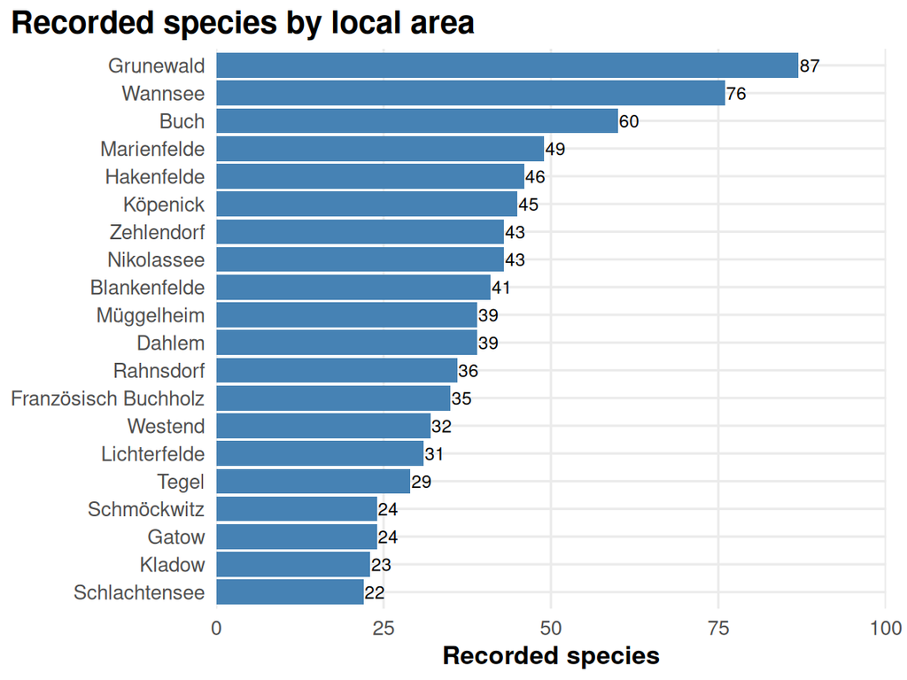

Figure 24: Recorded species by Berlin local area

```r
if (nrow(berlin_district_counts) == 0) {
  empty_plot("Berlin local-area species counts are unavailable because polygons were not loaded.")
} else {
  berlin_district_counts |>
    arrange(desc(species)) |>
    slice_head(n = 20) |>
    ggplot(aes(x = reorder(district, species), y = species)) +
    geom_col(fill = "steelblue") +
    geom_text(aes(label = format_number(species)), hjust = -0.05, size = 3) +
    coord_flip() +
    plot_labs(title = "Recorded species by local area", x = NULL, y = "Recorded species") +
    scale_y_continuous(labels = scales::comma_format(), expand = expansion(mult = c(0, 0.15))) +
    theme_gtree()
}
```

Grunewald and Wannsee also have the highest recorded species counts. Buch stands out with 60 species despite having fewer observations than Dahlem, suggesting that observation volume and recorded richness do not always rise together.

The gap between Figure 23 and Figure 24 is itself informative. Grunewald’s lead in species is nowhere near as extreme as its lead in observations, which is what one would expect from saturation: once an area has been visited often enough, additional visits mostly re-record species already on the list. Recorded richness is bounded by the local flora, whereas observation counts are bounded only by observer enthusiasm. Comparing richness across areas with such unequal effort would need rarefaction of the kind applied to continents in Part I and to US regions in Part III; without it, Figure 24 should be read as “species found so far”, not as a diversity ranking.

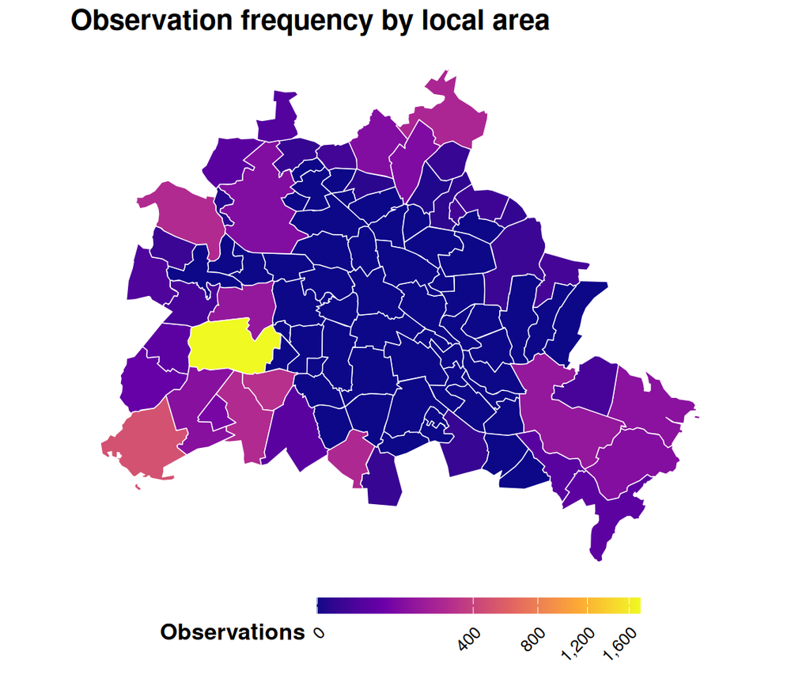

Figure 25: Observation frequency by Berlin local area

```r
if (has_berlin_districts && nrow(berlin_district_counts) > 0) {
  berlin_district_map <- berlin_districts |>
    left_join(berlin_district_counts, by = "district") |>
    mutate(observations = dplyr::coalesce(observations, 0L))
  berlin_district_map_plot <- simplify_for_plot(berlin_district_map, tolerance = 0.0005)
  ggplot(berlin_district_map_plot) +
    geom_sf(aes(fill = observations), color = "white", linewidth = 0.25) +
    scale_fill_viridis_c(
      option = "C", trans = "sqrt", labels = scales::comma_format(),
      guide = guide_colorbar(
        barwidth = 12, barheight = 0.6,
        label.theme = element_text(angle = 45, hjust = 1, size = 9)
      )
    ) +
    plot_labs(title = "Observation frequency by local area", subtitle = NULL, fill = "Observations") +
    theme_map_gtree()
} else {
  empty_plot("Berlin local-area map is unavailable because polygons were not loaded.")
}
```

Figure 25 shows the same counts in their spatial arrangement. Square-root scaling keeps both high- and medium-count local areas visible.

The map confirms a strong hotspot around Grunewald in western Berlin. Most central areas have low counts, while several outer areas in the southwest, north and southeast show moderate recording activity.

## 10.6 Top recorded species in Berlin

- *Which tree species are recorded most often in Berlin, and are the species labels trustworthy?*

```r
berlin_named <- add_species_display_name(berlin)

berlin_top_species <- berlin_named |>
  count(level3_species, species_display_name, display_common_name_en, sort = TRUE, name = "observations") |>
  mutate(share = observations / sum(observations))

# The top-species table was removed; the bar chart below shows the same ranking.
```

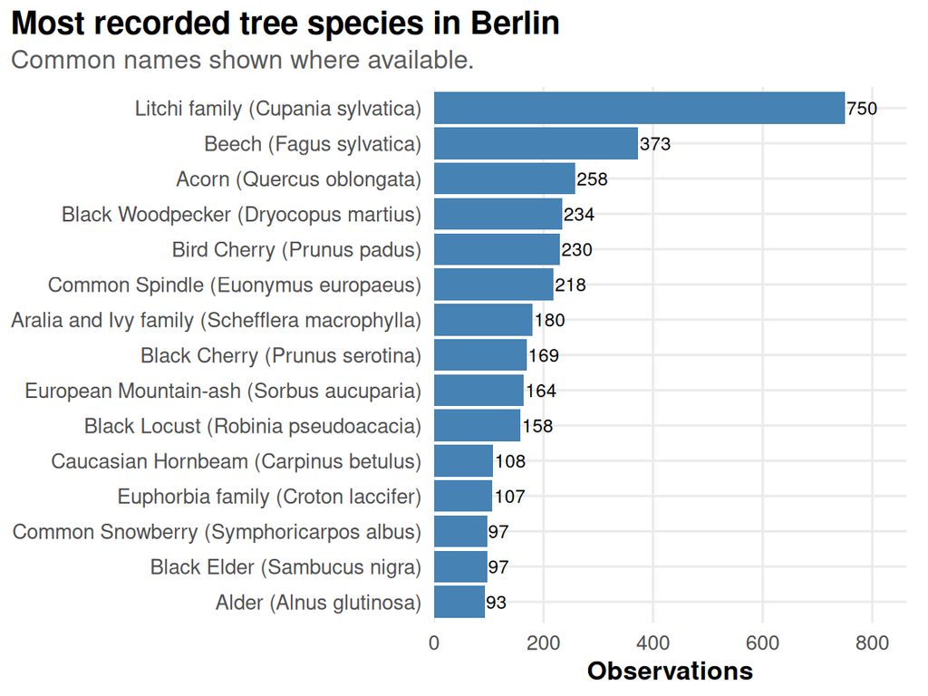

Figure 26: Most recorded tree species in Berlin

```r
berlin_top_species |>
  slice_head(n = 15) |>
  ggplot(aes(x = reorder(species_display_name, observations), y = observations)) +
  geom_col(fill = "steelblue") +
  geom_text(aes(label = format_number(observations)), hjust = -0.05, size = 3) +
  coord_flip() +
  scale_y_continuous(labels = scales::comma_format(), expand = expansion(mult = c(0, 0.15))) +
  plot_labs(title = "Most recorded tree species in Berlin",
       subtitle = "Common names shown where available.",
       x = NULL, y = "Observations") +
  theme_gtree()
```

Figure 26 should be read with considerable caution, because it is the one figure in this part where the *labels* — not just the counts — are demonstrably wrong.

*Cupania sylvatica* tops the ranking, with roughly 2 times the observations of the next species. That result is not credible: *Cupania* is a Neotropical genus that does not grow wild in Germany. The explanation is visible on the chart itself. The common names come from GBIF via `add_species_display_name()`, and the label rendered for this taxon is **“Litchi family”** — a *family* vernacular, not a species name. Its `species_key` (6657) is a family-rank GBIF identifier for Sapindaceae, not a species key.

The same fault recurs. `Croton laccifer` resolves to “Euphorbia family”, `Schefflera macrophylla` to “Aralia and Ivy family”, `Dombeya acerifolia` to “Mallow Family”, `Salix arbutifolia` to “Willow Family”. In every case a four-digit family-rank key sits where a seven-digit species key should be. The pattern suggests that where GlobalGeoTree could resolve a record only to family, it back-filled `level3_species` with an arbitrary — usually tropical — member of that family instead of leaving it blank. Read that way, the entries are not exotic at all: the Sapindaceae records are almost certainly maples, the Araliaceae records ivy, and the Malvaceae records limes — all thoroughly unremarkable Berlin trees wearing the wrong names. Across Germany these family-rank rows account for 11.4% of observations.

A second, unrelated problem sits alongside it: *Dryocopus martius*, the black woodpecker, is the second most recorded taxon among the German species carrying a GBIF key, with 11,353 records — behind only beech. It is a bird. Whatever filter was meant to restrict GlobalGeoTree to trees has let at least one animal through at high volume.

Both faults are inherited from the upstream dataset rather than introduced here, and neither is repaired in this report. The consequence is that this ranking cannot be read as a description of Berlin’s tree stock: it is a description of Berlin’s *labels*, and some of them are wrong. Species-level use of the German subset would need the taxonomy validated against GBIF ranks first. The spatial and source-level findings elsewhere in Part II do not depend on species identity and are unaffected.

## 10.7 Berlin oak tree groups

- *Where are recorded oak trees concentrated in Berlin, and how could these records support a follow-up analysis?*

This section demonstrates a possible practical application of the dataset. The oak processionary moth (*Thaumetopoea processionea*) can cause allergic reactions and skin irritation near affected oak trees. Mapping recorded oak locations provides a starting point that could be compared with official tree inventories and pest-surveillance data; GlobalGeoTree observations alone do not show whether the moth is present or whether a public warning is needed.

```r
berlin_oaks <- berlin |>
  filter(
    stringr::str_to_lower(as.character(level2_genus)) == "quercus" |
      stringr::str_detect(stringr::str_to_lower(as.character(level3_species)), "^quercus\\b")
  )

berlin_oak_summary <- tibble::tibble(
  metric = c("Berlin oak observations", "Berlin recorded oak species", "Share of Berlin observations that are oak"),
  value = c(
    format_number(nrow(berlin_oaks)),
    format_number(n_distinct(berlin_oaks$level3_species)),
    ifelse(nrow(berlin) > 0, format_percent(nrow(berlin_oaks) / nrow(berlin)), "0%")
  )
)
nice_table(berlin_oak_summary, "Berlin oak observation summary")
```

Berlin oak observation summary

| metric | value |
| --- | --- |
| Berlin oak observations | 258 |
| Berlin recorded oak species | 1 |
| Share of Berlin observations that are oak | 5.0% |

```r
if ("district" %in% names(berlin_oaks) && any(!is.na(berlin_oaks$district))) {
  berlin_oak_area_counts <- berlin_oaks |>
    filter(!is.na(district), district != "") |>
    count(district, name = "oak_observations", sort = TRUE)
} else {
  berlin_oak_area_counts <- tibble::tibble()
}

# Counts feed the oak map and the bar chart below; the table view was removed as redundant.
```

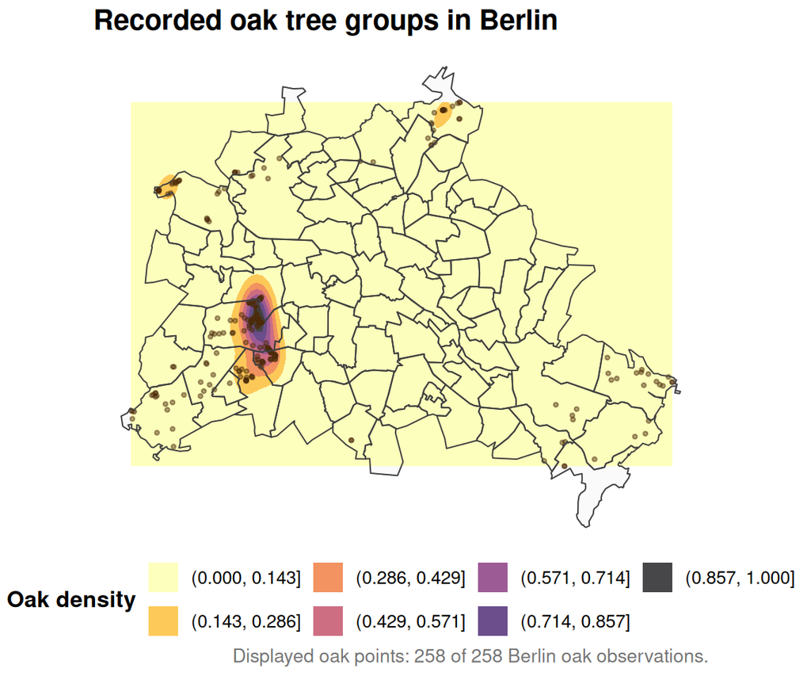

Figure 27: Recorded oak tree groups in Berlin

```r
berlin_oak_points_for_map <- sample_up_to(berlin_oaks, max_berlin_points)

if (nrow(berlin_oak_points_for_map) == 0) {
  empty_plot("No Berlin oak observations were available for the oak map.")
} else if (has_berlin_districts) {
  p <- ggplot() +
    geom_sf(data = berlin_districts_plot, fill = "gray98", color = "gray75", linewidth = 0.25)
  if (nrow(berlin_oak_points_for_map) >= 3) {
    p <- p +
      stat_density_2d_filled(data = berlin_oak_points_for_map,
                             aes(x = longitude, y = latitude, fill = after_stat(level)),
                             contour_var = "ndensity", bins = 7, alpha = 0.72)
  }
  p +
    geom_point(data = berlin_oak_points_for_map, aes(x = longitude, y = latitude),
               color = "#4d2c0b", alpha = 0.45, size = 0.75) +
    geom_sf(data = berlin_districts_plot, fill = NA, color = "gray25", linewidth = 0.35) +
    coord_sf() +
    scale_fill_viridis_d(option = "B", direction = -1, name = "Oak density") +
    plot_labs(title = "Recorded oak tree groups in Berlin",
         caption = paste("Displayed oak points:", format_number(nrow(berlin_oak_points_for_map)), "of", format_number(nrow(berlin_oaks)), "Berlin oak observations."),
         x = NULL, y = NULL) +
    theme_map_gtree()
} else {
  ggplot(berlin_oak_points_for_map, aes(x = longitude, y = latitude)) +
    geom_point(color = "#4d2c0b", alpha = 0.45, size = 0.75) +
    coord_fixed() +
    plot_labs(title = "Recorded oak tree groups in Berlin",
         subtitle = "Local-area borders were unavailable, so this map uses the Berlin bounding-box fallback.",
         x = "Longitude", y = "Latitude") +
    theme_gtree()
}
```

The oak pattern in Figure 27 closely follows the overall pattern in Figure 22, with the strongest concentration in the west. The oak map therefore mainly reflects where recording is most intensive, not where oaks are most common.

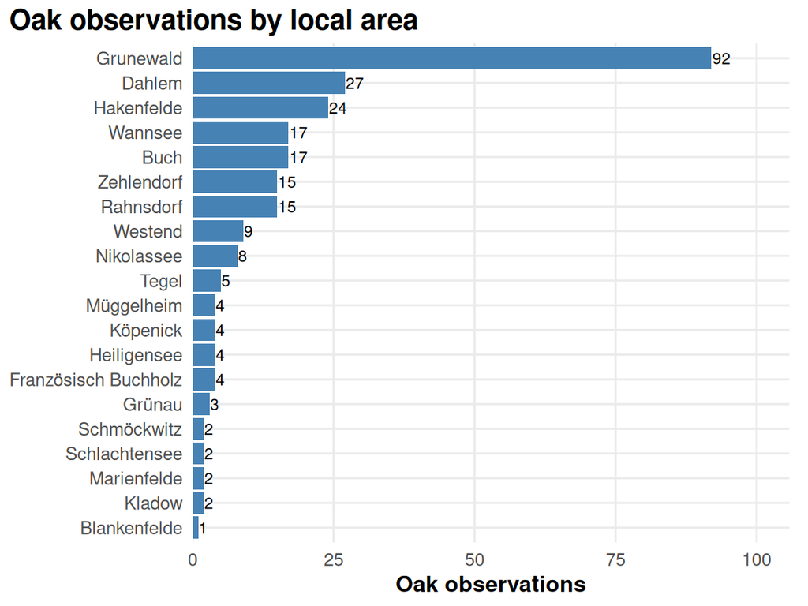

Figure 28: Recorded oak observations by Berlin local area

```r
if (nrow(berlin_oak_area_counts) == 0) {
  empty_plot("Berlin oak local-area counts are unavailable.")
} else {
  berlin_oak_area_counts |>
    slice_head(n = 20) |>
    ggplot(aes(x = reorder(district, oak_observations), y = oak_observations)) +
    geom_col(fill = "steelblue") +
    geom_text(aes(label = format_number(oak_observations)), hjust = -0.05, size = 3) +
    coord_flip() +
    scale_y_continuous(labels = scales::comma_format(), expand = expansion(mult = c(0, 0.15))) +
    plot_labs(title = "Oak observations by local area", x = NULL, y = "Oak observations") +
    theme_gtree()
}
```

Grunewald, Dahlem and other highly sampled areas also contain most oak records. Because the full dataset is spatially biased, the oak subset inherits the same bias, so these counts should not be read as a ranking of true oak abundance.

It is worth stating plainly what this means for the application proposed above, because the answer is negative. A processionary-moth warning system needs to know where oaks *are*; Figure 28 shows where oaks were *looked at*. An area with many oaks and no observers is indistinguishable here from an area with no oaks, and those are exactly the areas a public-health warning would most need to reach. GlobalGeoTree cannot supply this on its own — the oak records are usable as a supplementary layer over an official tree inventory, which has known coverage, but not as a substitute for one. The value of this section is in showing what the dataset would need to be joined against, rather than in the map itself.

# 11 Baden-Württemberg and North Rhine-Westphalia

- *Is Berlin’s spatial concentration of observations a Berlin-specific pattern, or is it typical for German regions?*

The Berlin analysis above revealed that observations are heavily concentrated in a single location. To investigate, we compare Berlin with North Rhine-Westphalia (NRW) and Baden-Württemberg — the first and third largest federal states by observation count. For each state, a density map and a NUTS3 district choropleth show where observations are concentrated.

One caveat applies to the whole comparison. Berlin covers about 890 km² and is divided into small local areas; Baden-Württemberg and NRW each cover roughly 35,000 km² and are divided into much larger NUTS3 districts. Measured concentration depends on the size of the units doing the measuring, so “Berlin is more concentrated” cannot be read straight off the maps — the comparison below rests on the *shape* of the density surfaces, which are computed from coordinates rather than administrative units, and treats the choropleths as supporting detail only.

## 11.1 Baden-Württemberg

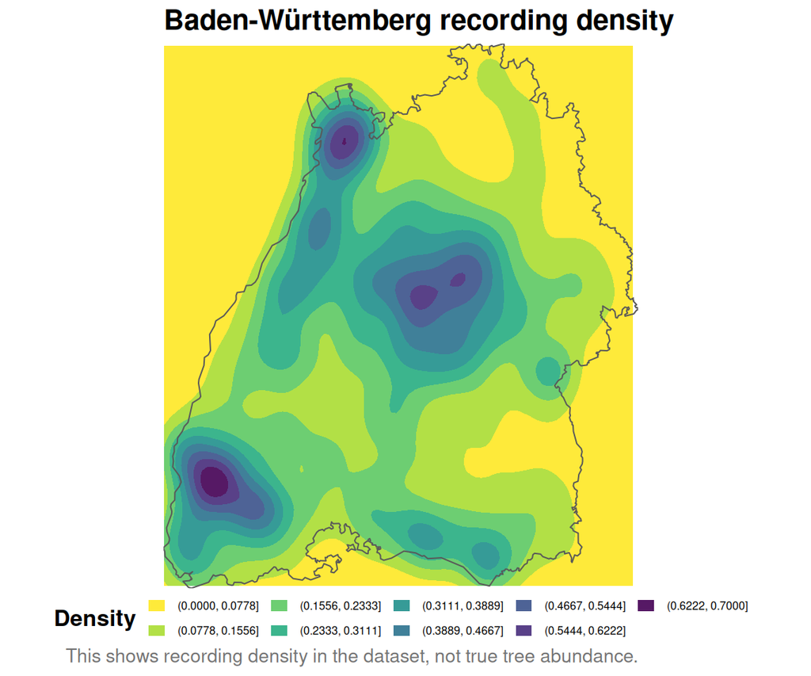

Figure 29: Baden-Württemberg observation density

```r
bw_points_for_map <- sample_up_to(bw, max_bw_points)
bw_boundary_for_map <- if (has_bw_boundary) bw_boundary_plot else NULL

if (nrow(bw_points_for_map) < 3) {
  empty_plot("Not enough Baden-Württemberg observations were available for the density map.")
} else {
  plot_filled_density_map(
    points_data = bw_points_for_map, boundary_data = bw_boundary_for_map,
    title = "Baden-Württemberg recording density",
    subtitle = NULL,
    caption = "This shows recording density in the dataset, not true tree abundance.",
    bins = 9, alpha = 0.90
  )
}
```

In Baden-Württemberg recording is stronger in the west and south than in many eastern areas. Several hotspots are visible, especially in the southwest, northwest and central part of the state. Unlike Berlin, where observations are concentrated mainly around one western hotspot, Baden-Württemberg has several separate centres of recording activity.

### 11.1.1 Baden-Württemberg observations by NUTS3 district

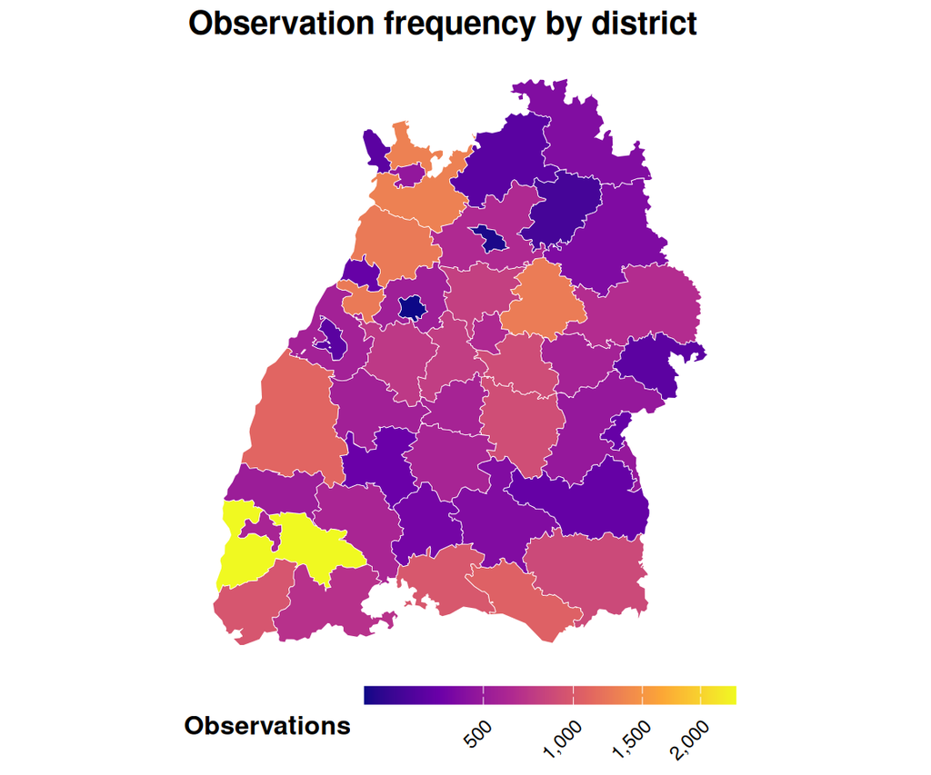

Figure 30: Baden-Württemberg observation frequency by NUTS3 district

```r
if (is.null(bw_district_map)) {
  empty_plot("Baden-Württemberg district map is unavailable because NUTS3 polygons were not loaded.")
} else {
  ggplot(bw_district_map_plot) +
    geom_sf(aes(fill = observations), color = "white", linewidth = 0.15) +
    scale_fill_viridis_c(
      option = "C", trans = "sqrt", labels = scales::comma_format(),
      guide = guide_colorbar(
        barwidth = 12, barheight = 0.6,
        label.theme = element_text(angle = 45, hjust = 1, size = 9)
      )
    ) +
    plot_labs(title = "Observation frequency by district", subtitle = NULL, fill = "Observations") +
    theme_map_gtree()
}
```

Square-root scaling is applied so that a few very high-count districts do not wash out variation among the rest.

Figure 30 confirms that observations are unevenly distributed. The highest counts occur in the far southwest, while several western, northern and southern districts also have relatively high totals. Many central and eastern districts contribute fewer records.

## 11.2 North Rhine-Westphalia

NRW serves the same role as Baden-Württemberg: a state-level comparison point for Berlin.

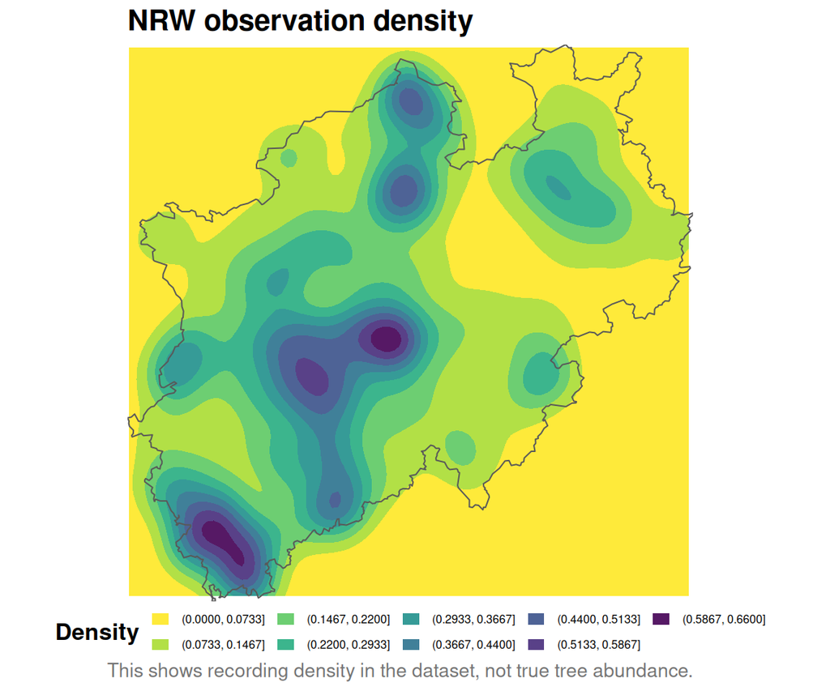

Figure 31: NRW observation density

```r
nrw_points_for_map <- sample_up_to(nrw, max_nrw_points)
nrw_boundary_for_map <- if (has_nrw_boundary) nrw_boundary_plot else NULL

if (nrow(nrw_points_for_map) < 3) {
  empty_plot("Not enough NRW observations were available for the density maps.")
} else {
  plot_filled_density_map(
    points_data = nrw_points_for_map, boundary_data = nrw_boundary_for_map,
    title = "NRW observation density",
    subtitle = NULL,
    caption = "This shows recording density in the dataset, not true tree abundance.",
    bins = 9, alpha = 0.90
  )
}
```

NRW has several observation hotspots rather than one dominant centre. High recording density appears in the southwest, central-west and north, with smaller clusters in the east. This is more dispersed than Berlin’s strongly concentrated western hotspot and helps explain the broad area of high density seen in western Germany in Figure 14.

### 11.2.1 NRW observations by NUTS3 district

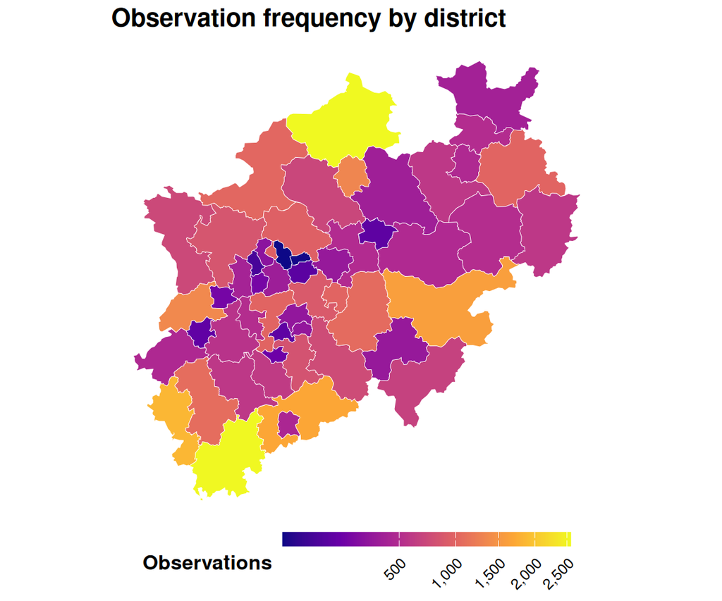

Figure 32: NRW observation frequency by NUTS3 district

```r
if (is.null(nrw_district_map)) {
  empty_plot("NRW district map is unavailable because NUTS3 polygons were not loaded.")
} else {
  ggplot(nrw_district_map_plot) +
    geom_sf(aes(fill = observations), color = "white", linewidth = 0.15) +
    scale_fill_viridis_c(
      option = "C", trans = "sqrt", labels = scales::comma_format(),
      guide = guide_colorbar(
        barwidth = 12, barheight = 0.6,
        label.theme = element_text(angle = 45, hjust = 1, size = 9)
      )
    ) +
    plot_labs(title = "Observation frequency by district", subtitle = NULL, fill = "Observations") +
    theme_map_gtree()
}
```

As above, square-root scaling is used so that dominant districts do not obscure the rest of the distribution.

Figure 32 confirms that records are uneven but spread across much of NRW. A few northern and southern districts have the highest totals, while many central districts show medium counts. Compared with Baden-Württemberg, NRW has a similarly multi-centred pattern; compared with Berlin, its observations are less dependent on one local area.

Comparing Figure 29 and Figure 31 with Figure 22 answers the question this section opened with. Observations in Baden-Württemberg and NRW are spread much more evenly across their territories, with multiple distinct hotspots corresponding to major cities and populated areas, whereas Berlin’s observations are heavily concentrated in a single location. Berlin’s concentration is therefore Berlin-specific rather than typical of German regions, and the Berlin subset is better described as localised recording activity than as a representative spatial sample of the city’s tree cover.

# 12 Germany: Conclusions

Part II asked where tree observations in Germany come from, who records them, and whether the national picture holds at city scale. Five findings stand out.

**Recording is a western and southwestern phenomenon, and it tracks people.** Figure 14 and Figure 15 agree: intensity is highest in the west and south, with an isolated hotspot at Berlin and thin coverage across the east and northeast. At state level, North Rhine-Westphalia leads, followed by Bavaria, Baden-Württemberg and Lower Saxony — which is close to Germany’s population ranking. Because the counts are raw rather than normalised, the federal state comparison cannot separate tree cover from observer density, and the population ordering suggests observers are doing most of the work.

**No single platform describes Germany, and the mix changes with scale.** Pl@ntNet auto ID contributes 46.9% of German records and the three largest sources 82.1%, so national patterns are effectively the patterns of three platforms. That composition is not the global one — iNaturalist leads worldwide with 64.4% — and it is not Berlin’s either, where iNaturalist returns to the front with 60.3%. Global, national and city scales are each dominated by a different source, so source composition has to be established at the scale being analysed and never inherited from the level above.

**Berlin’s tree records describe a forest, not a city.** Grunewald alone holds 1,714 observations, 3.5 times the next local area, with the dense central boroughs contributing little. The expectation that a city-state would yield urban, street-tree recording is contradicted by its own data: what the Berlin subset captures is recreational recording in woodland and leafy periphery. The oak analysis inherits this bias exactly, which is why it cannot underpin a processionary-moth warning system without an official inventory to supply the coverage GlobalGeoTree lacks.

**That concentration is specific to Berlin.** Baden-Württemberg and NRW are multi-centred, with hotspots at their major population centres rather than at one site (Figure 29, Figure 31). Berlin differs in kind, not just degree — though the comparison spans very different areal units and should be read from the density surfaces rather than the choropleths.

**Species-level labels in the German subset are not trustworthy.** Around 11.4% of German observations carry family-rank GBIF keys behind plausible-looking species names, so the “tropical” trees topping the Berlin ranking are almost certainly maples, ivy and limes; a black woodpecker ranks second nationally. These faults come from the upstream dataset and are not repaired here. The spatial and source-level conclusions above do not depend on species identity, but any species-level use of this subset would need the taxonomy validated first.

Taken together, Part II measures **recording behaviour in Germany, not German tree cover**. Every pattern above — the western skew, the state ranking, the Berlin hotspot, the oak distribution — is better explained by where observers go and which app they use than by where trees grow. This does not make the data useless, but it fixes what it can answer: it is evidence about a sampling process, and only indirectly about the thing sampled.

# Part III: Distribution of the data in the United States

*— Santiago*

This part focuses on the US records and asks whether their distribution reflects ecological patterns, the way the data was collected, or a combination of both. Knowing which places and years contribute most of the observations is necessary before drawing conclusions about tree diversity from the dataset.

The analysis first describes national coverage and its regional imbalance. It then compares foliage categories, latitude profiles, and taxonomic richness. The final figures add the time dimension to show whether the geographical pattern changed as the number of records increased.

## 12.1 Pre-Processing

Rows labelled with the `US` country code were retained. Their coordinates were matched to state polygons from the `maps` package; points missed by the simplified coastal boundaries were linked to the closest state centre. The state names were then converted into the four Census regions — Northeast, South, Midwest, and West — so that comparisons would not be fragmented across fifty individual states.

Table 3 displays the working variables after this preparation.

```r
knitr::kable(head(us_df[, c("sample_id", "level0", "level1_family", "level2_genus",
                         "level3_species", "year", "longitude", "latitude",
                         "state", "region"), with=FALSE]), row.names = FALSE)
```

| sample_id | level0 | level1_family | level2_genus | level3_species | year | longitude | latitude | state | region |
| --- | --- | --- | --- | --- | --- | --- | --- | --- | --- |
| 2638129 | Deciduous Broadleaf | Actinidiaceae | Actinidia | Actinidia arguta | 2024 | -68.19505 | 44.37374 | maine | Northeast |
| 2638136 | Deciduous Broadleaf | Amaranthaceae | Chenopodium | Chenopodium album | 2021 | -73.93528 | 44.60028 | new york | Northeast |
| 2638137 | Deciduous Broadleaf | Amaranthaceae | Chenopodium | Chenopodium album | 2020 | -69.90992 | 44.22425 | maine | Northeast |
| 2638204 | Deciduous Broadleaf | Amaranthaceae | Chenopodium | Chenopodium album | 2024 | -73.08378 | 44.52931 | vermont | Northeast |
| 2638205 | Deciduous Broadleaf | Amaranthaceae | Chenopodium | Chenopodium album | 2024 | -73.01671 | 44.49624 | vermont | Northeast |
| 2638206 | Deciduous Broadleaf | Amaranthaceae | Chenopodium | Chenopodium album | 2024 | -72.91761 | 44.99943 | vermont | Northeast |

Table 3: First observations after preparing the US subset

The regional colours in Figure 33 remain unchanged from one graph to another. They come from the colour-blind-friendly Okabe-Ito palette.

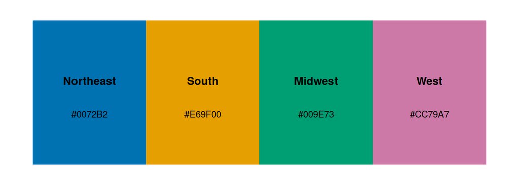

Figure 33: Regional colours used throughout the US analysis

```r
par(mar = c(1,1,1,1))
plot.new(); plot.window(xlim=c(0,4), ylim=c(0,1))
for (i in seq_along(region_colors)) {
  rect(i-1, 0, i, 1, col=region_colors[i], border=NA)
  text(i-.5, .58, names(region_colors)[i], font=2, cex=.9)
  text(i-.5, .35, region_colors[i], cex=.75)
}
```

## 12.2 United States overview

The initial overview separates national reach from sampling intensity. A dataset may include all major parts of the country and still be dominated by a few places.

For that reason, Figure 34 shows the individual coordinates, Figure 35 compares the regional totals, and Figure 36 identifies the cells where records accumulate most strongly.

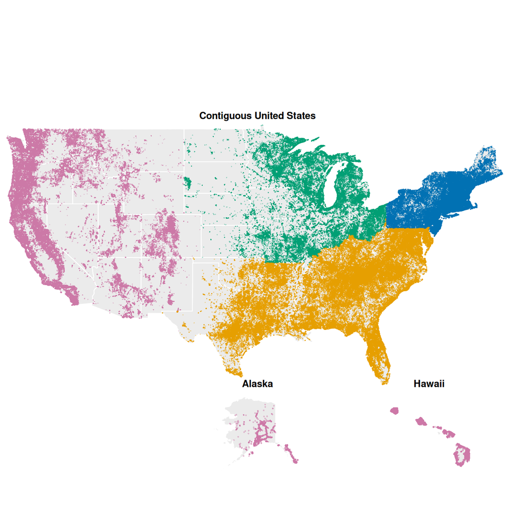

Figure 34: Location of US observations, coloured by Census region

```r
conus <- us_df[us_df$longitude >= -125 & us_df$longitude <= -66 &
            us_df$latitude >= 24 & us_df$latitude <= 50, ]
alaska <- us_df[us_df$state == "alaska", ]
hawaii <- us_df[us_df$state == "hawaii", ]

layout(matrix(c(1,1,1,1,2,3), nrow=2, byrow=TRUE), heights=c(3,1.25))
par(mar=c(3,3,2,1))
draw_conus()
points(conus$longitude, conus$latitude, pch=16, cex=.32,
       col=adjustcolor(region_colors[as.character(conus$region)], alpha.f=.35))
title("Contiguous United States", xlab="Longitude", ylab="Latitude")
par(mar=c(3,3,2,1))
maps::map("world", regions="USA", fill=TRUE, col="grey92", border="white",
    xlim=c(-170,-130), ylim=c(50,72))
points(alaska$longitude, alaska$latitude, pch=16, cex=.45,
       col=adjustcolor(region_colors["West"], alpha.f=.45)); title("Alaska")
maps::map("world", regions="USA", fill=TRUE, col="grey92", border="white",
    xlim=c(-161,-154), ylim=c(18,23))
points(hawaii$longitude, hawaii$latitude, pch=16, cex=.45,
       col=adjustcolor(region_colors["West"], alpha.f=.45)); title("Hawaii")
layout(1)
```

The points in Figure 34 cover most of the country, but not with the same intensity. Texas, California, Florida, and the Northeast form visible clusters, whereas the Great Plains and much of the interior West are sparsely represented. Accessibility and the location of contributors probably explain part of this contrast, so the map cannot be read as a map of tree abundance.

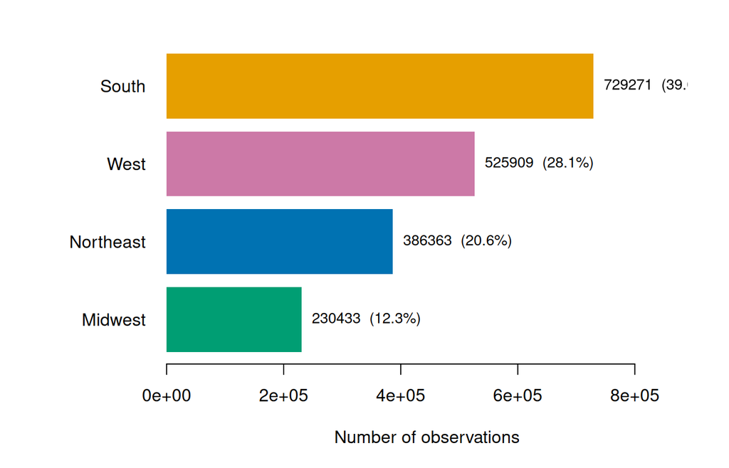

Figure 35: Contribution of each US region to the complete US subset

```r
region_n <- sort(table(us_df$region), decreasing=TRUE)
par(mar=c(5,8,2,2))
bp <- barplot(rev(region_n), horiz=TRUE, las=1, border=NA,
              col=region_colors[names(rev(region_n))],
              xlim=c(0,max(region_n)*1.22), xlab="Number of observations")
text(rev(region_n), bp,
     labels=paste0(rev(region_n), "  (", pct(rev(region_n)/sum(region_n)), ")"),
     pos=4, cex=.85)
```

The regional counts in Figure 35 make the imbalance more explicit. The South supplies the largest share of records, followed by the West. The Northeast and Midwest have considerably fewer rows. These percentages refer to dataset participation and should not be interpreted as regional forest shares.

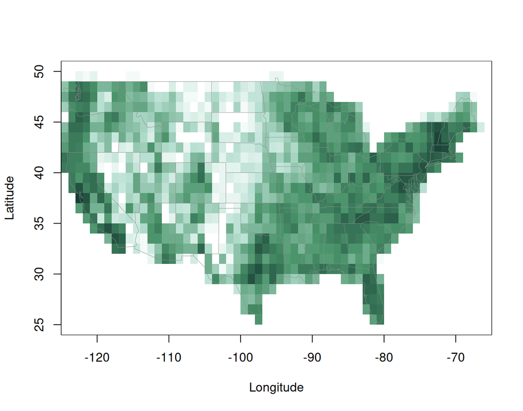

Figure 36: Local concentration of records across the contiguous United States

```r
xb <- seq(-125,-65,by=1); yb <- seq(24,51,by=1)
h <- table(cut(conus$longitude,xb), cut(conus$latitude,yb))
image(xb[-length(xb)]+.5, yb[-length(yb)]+.5, log10(h+1),
      col=colorRampPalette(c("white","#B8E0D2","#4C956C","#173F35"))(40),
      xlab="Longitude", ylab="Latitude", useRaster=TRUE)
maps::map("state", add=TRUE, col="grey55", lwd=.45)
```

The grid representation in Figure 36 isolates the main hotspots around central Texas, southern California, Florida, and the northeastern corridor. Pale inland cells indicate limited sampling rather than an absence of trees.

Overall, the US subset has a wide footprint but an uneven internal balance. The following comparisons are therefore interpreted as patterns within the available records, not as a national census.

## 12.3 Spatial distribution of foliage types

The next step is to compare the kinds of trees recorded in different places. Foliage categories summarise important ecological strategies: broad or needle-shaped leaves and evergreen or deciduous behaviour respond differently to cold, drought, and seasonality.

The small maps in Figure 37 preserve the spatial detail. Figure 38 converts those records into regional percentages, while Figure 39 removes the administrative boundaries and follows the north–south gradient directly.

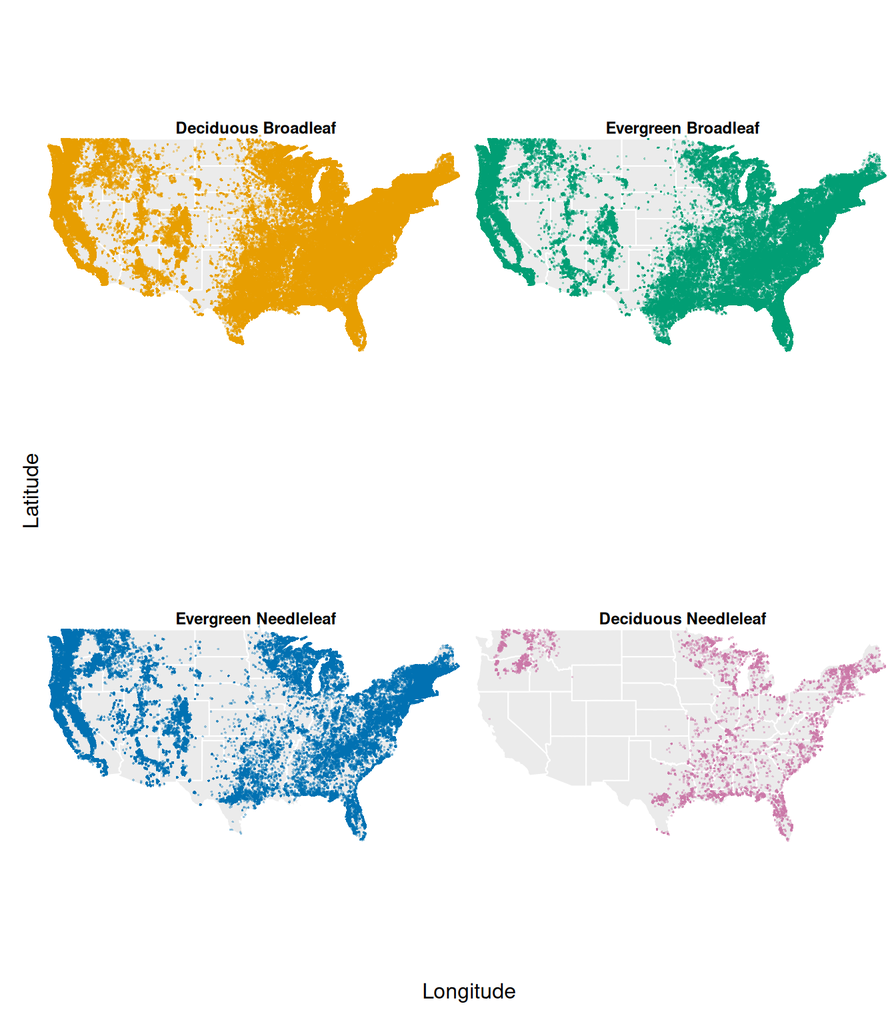

Figure 37: US locations recorded for each foliage category

```r
observed_types <- names(sort(table(conus$level0), decreasing=TRUE))
op <- par(mfrow=c(2,2), mar=c(2,2,2,.5), oma=c(2,2,0,0))
for (tp in observed_types) {
  z <- conus[conus$level0 == tp,]
  draw_conus()
  points(z$longitude,z$latitude,pch=16,cex=.3,
         col=adjustcolor(foliage_colors[tp],alpha.f=.4))
  title(tp, cex.main=.9)
}
if (length(observed_types)<4) plot.new()
mtext("Longitude",1,outer=TRUE); mtext("Latitude",2,outer=TRUE)
par(op)
```

The categories in Figure 37 do not occupy identical spaces. Deciduous Broadleaf is found throughout the contiguous states and is particularly visible in the East and South. Evergreen Broadleaf is concentrated farther south and on the Pacific coast, while Evergreen Needleleaf forms strong western and northern clusters. Deciduous Needleleaf is present in pink, but its 10,951 records make it much rarer than the other three categories.

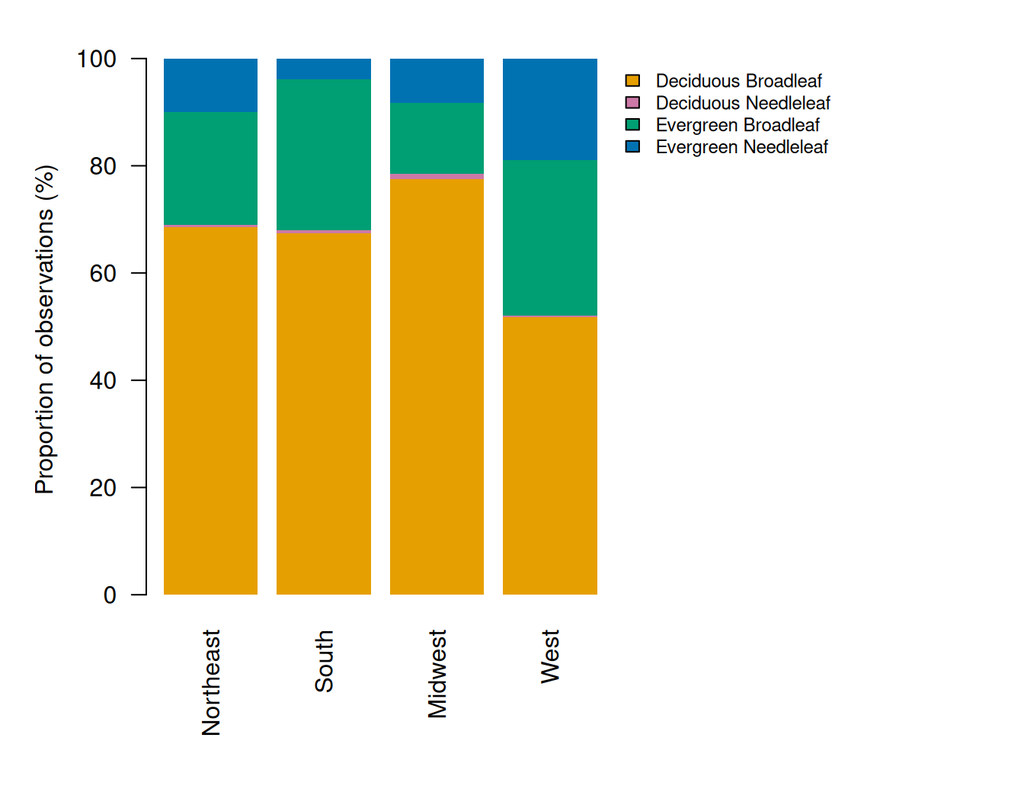

Figure 38: Foliage composition within each US region

```r
fol_region <- prop.table(
  table(us_df$level0, us_df$region),
  2
) * 100

fol_region <- fol_region[
  , colSums(fol_region) > 0,
  drop = FALSE
]

# Larger right margin for the legend
par(mar = c(7, 5, 2, 14), xpd = TRUE)

barplot(
  fol_region,
  col = foliage_colors[rownames(fol_region)],
  border = NA,
  las = 2,
  ylab = "Proportion of observations (%)"
)

legend(
  "topright",
  inset = c(-0.48, 0),
  legend = rownames(fol_region),
  fill = foliage_colors[rownames(fol_region)],
  bty = "n",
  cex = 0.75
)
```

Using percentages in Figure 38 prevents the South’s larger sample from dominating the comparison. Deciduous Broadleaf remains the largest group everywhere, although its share varies greatly. Evergreen Broadleaf reaches its largest regional shares in the South and West, while Evergreen Needleleaf is especially prominent in the West. Deciduous Needleleaf occurs in every region but never exceeds a little over 1%. Regional climate is one plausible contributor to these differences.

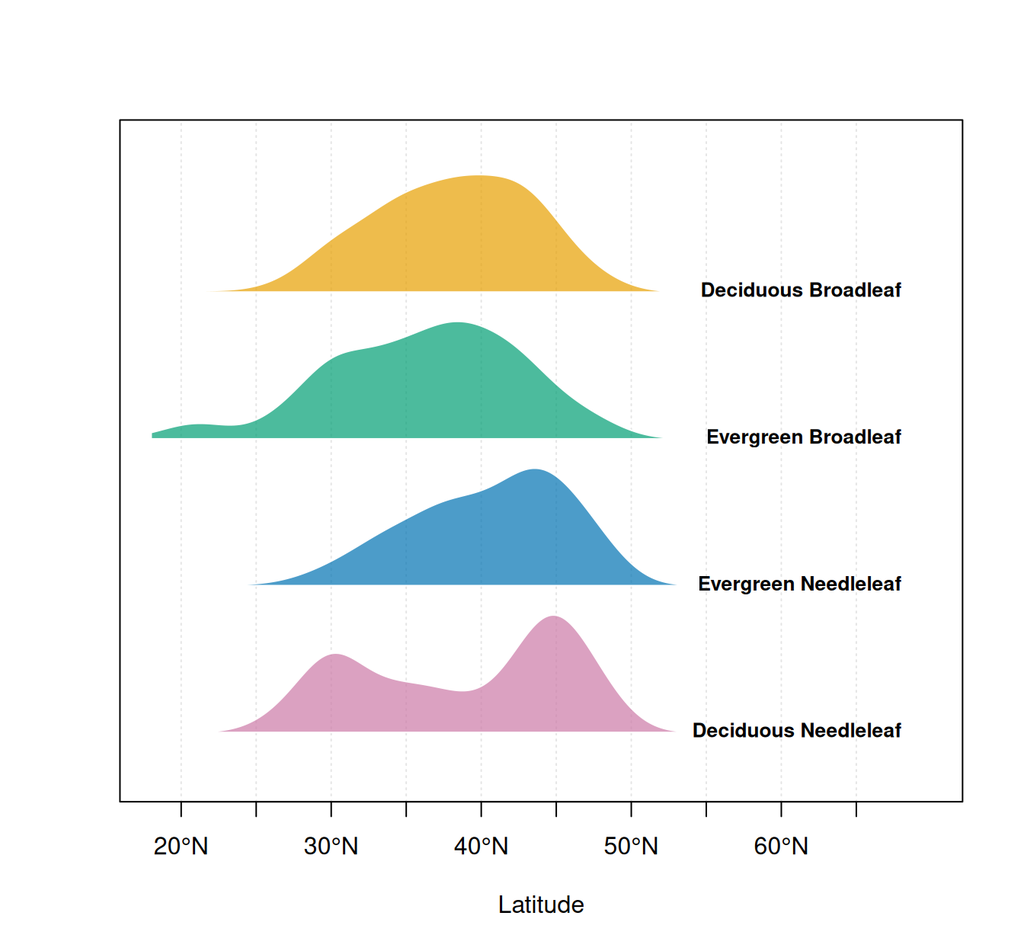

Figure 39: Latitude profiles of the foliage categories

```r
types <- names(sort(table(us_df$level0), decreasing=FALSE))
plot(NA,xlim=c(18,70),ylim=c(.7,length(types)+1),axes=FALSE,
     xlab="Latitude",ylab="")
axis(1,at=seq(20,65,5),labels=paste0(seq(20,65,5),"°N"))
abline(v=seq(20,65,5),col="grey90",lty=3)
for(i in seq_along(types)){
  z <- us_df$latitude[us_df$level0==types[i]]
  den <- density(z,from=18,to=68,bw=2)
  yy <- i + .8*den$y/max(den$y)
  polygon(c(den$x,rev(den$x)),c(rep(i,length(den$x)),rev(yy)),
          col=adjustcolor(foliage_colors[types[i]],alpha.f=.7),border="white")
  text(69,i,types[i],pos=2,cex=.82,font=2)
}
box()
```

The curves in Figure 39 overlap, but their peaks occur in different places. Evergreen Broadleaf has a clear southern component, including Hawaii, whereas Evergreen Needleleaf is weighted toward the northern half of the country. Deciduous Broadleaf covers the broadest span of the contiguous states. Deciduous Needleleaf is much less frequent but is not absent: its pink curve has concentrations around 30°N and 45°N.

These shifts support the idea that climate helps structure foliage type. Moving north usually changes temperature, season length, and frost exposure. Still, latitude does not measure climate directly, and other factors — precipitation, elevation, soil, land use, historical range, and sampling density — change at the same time. The figure therefore provides evidence of association, not a causal estimate.

## 12.4 Taxonomic richness by region

Taxonomic richness is measured here at three levels: family, genus, and species. Simple totals are useful, but they favour regions with more observations because additional records create more opportunities to encounter a new taxon.

Table 4 and Figure 40 present the unadjusted counts. Figure 41 then places the regions on a common sampling scale. The last visualisation, Figure 42, changes the question from “how many species?” to “how geographically concentrated is each common species?”

```r
taxa_region <- as.data.frame(us_df[, .(
  Foliage=uniqueN(level0),
  Families=uniqueN(level1_family),
  Genera=uniqueN(level2_genus),
  Species=uniqueN(level3_species),
  Observations=.N
), by=.(Region=region)])
taxa_region <- taxa_region[order(-taxa_region$Observations),]
knitr::kable(taxa_region,row.names=FALSE)
```

| Region | Foliage | Families | Genera | Species | Observations |
| --- | --- | --- | --- | --- | --- |
| South | 4 | 138 | 490 | 1626 | 729271 |
| West | 4 | 131 | 497 | 1811 | 525909 |
| Northeast | 4 | 86 | 203 | 653 | 386363 |
| Midwest | 4 | 84 | 199 | 660 | 230433 |

Table 4: Recorded taxonomic diversity and sample size by region

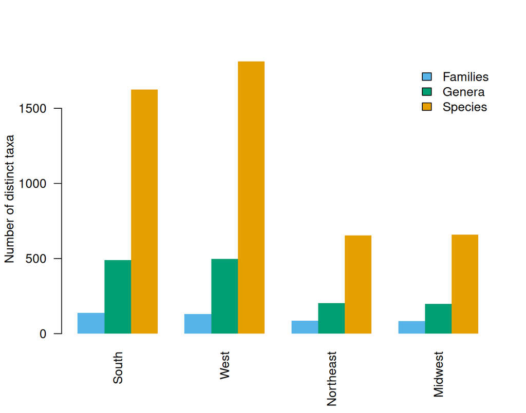

Figure 40: Unadjusted family, genus, and species counts by region

```r
rich_mat <- t(as.matrix(taxa_region[,c("Families","Genera","Species")]))
colnames(rich_mat) <- taxa_region$Region
barplot(rich_mat,beside=TRUE,border=NA,
        col=c("#56B4E9","#009E73","#E69F00"),
        ylab="Number of distinct taxa",las=2)
legend("topright",legend=rownames(rich_mat),
       fill=c("#56B4E9","#009E73","#E69F00"),bty="n")
```

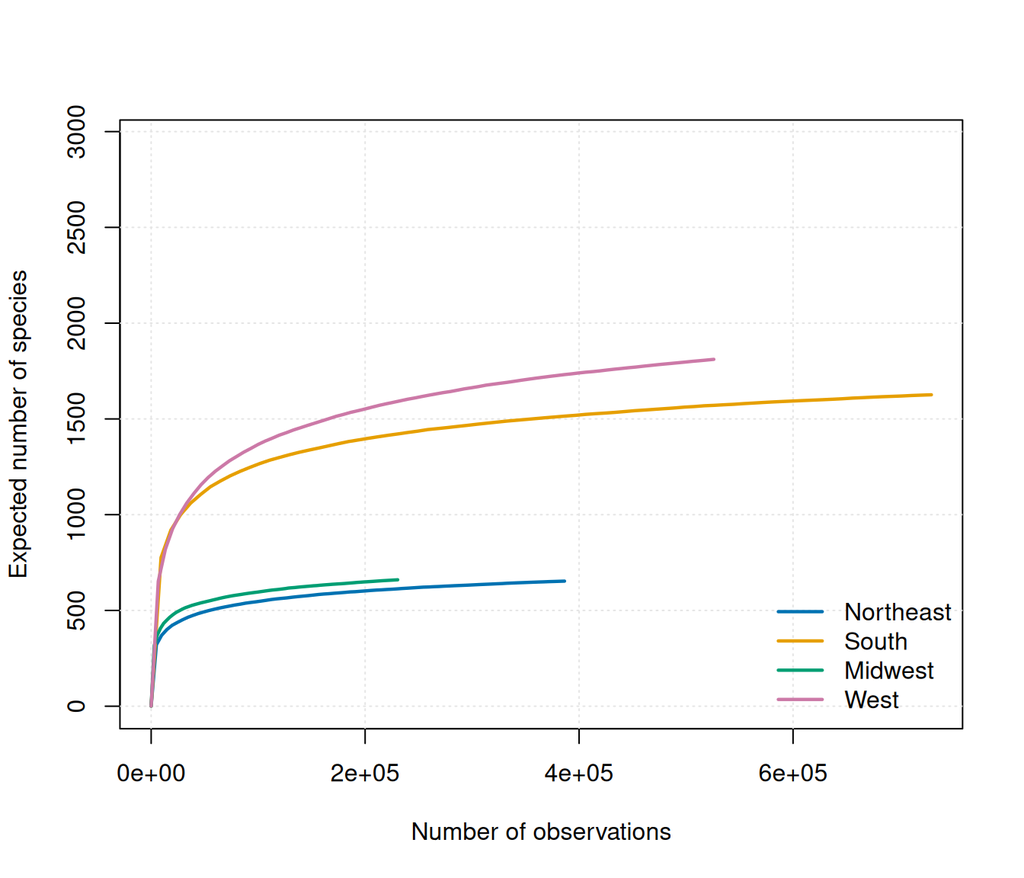

Figure 41: Growth of recorded species richness as regional sample size increases

```r
set.seed(42)
plot(NA,xlim=c(0,max(table(us_df$region))),ylim=c(0,length(unique(us_df$level3_species))),
     xlab="Number of observations",ylab="Expected number of species")
grid(col="grey90")
for(r in levels(us_df$region)){
  sp <- us_df$level3_species[us_df$region==r]
  steps <- unique(round(seq(1,length(sp),length.out=min(80,length(sp)))))
  curves <- replicate(20,{
    ord <- sample(sp)
    cum <- cumsum(!duplicated(ord))
    cum[steps]
  })
  lines(steps,rowMeans(curves),lwd=2.2,col=region_colors[r])
}
legend("bottomright",legend=levels(us_df$region),col=region_colors,lwd=2.2,bty="n")
```

In Figure 41, regions can be compared at the same horizontal position and therefore at the same number of sampled records. The curves reveal how quickly additional observations continue to add species in each region. Comparing them at a shared sample size separates part of the diversity pattern from the very different regional record totals.

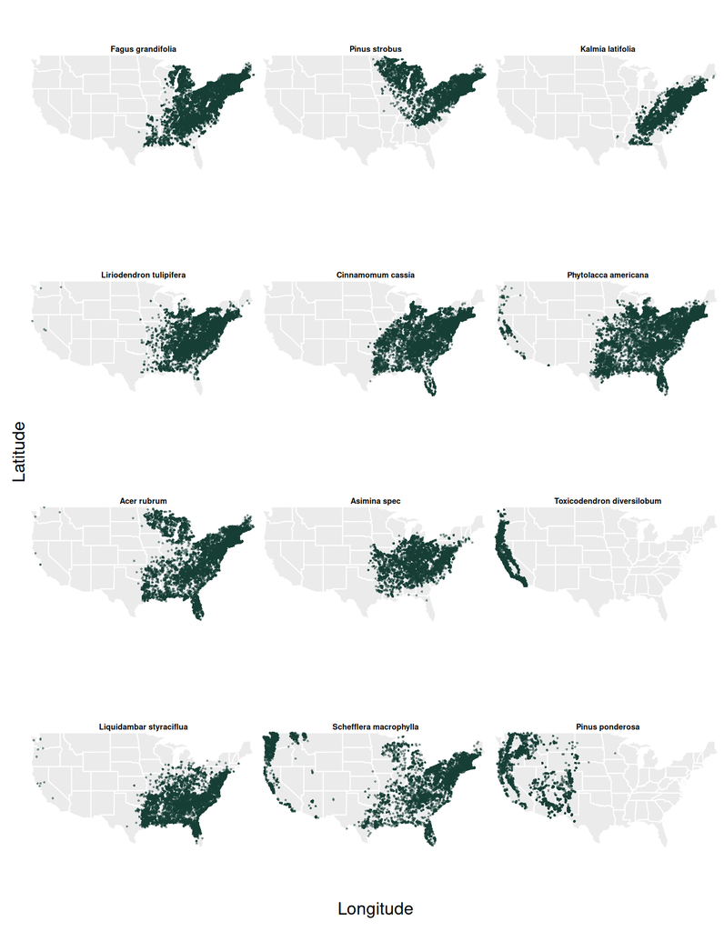

Figure 42: Observed ranges of the 12 most frequent species in the contiguous states

```r
top_species <- names(head(sort(table(conus$level3_species),decreasing=TRUE),12))
op <- par(mfrow=c(4,3),mar=c(1.5,1.5,2,.5),oma=c(2,2,0,0))
for(sp in top_species){
  z <- conus[conus$level3_species==sp,]
  draw_conus()
  points(z$longitude,z$latitude,pch=16,cex=.45,
         col=adjustcolor("#173F35",alpha.f=.55))
  title(sp,cex.main=.68)
}
mtext("Longitude",1,outer=TRUE);mtext("Latitude",2,outer=TRUE)
par(op)
```

## 12.5 Changes in the distribution over time

All previous figures combine ten observation years into one picture. This can hide changes in participation, especially for data coming mainly from citizen-science platforms.

The bars and line in Figure 43 compare annual volume with the number of represented states. Figure 44 identifies which parts of the country produce the increase, and Figure 45 checks whether later records spread into new territory or reinforce existing hotspots.

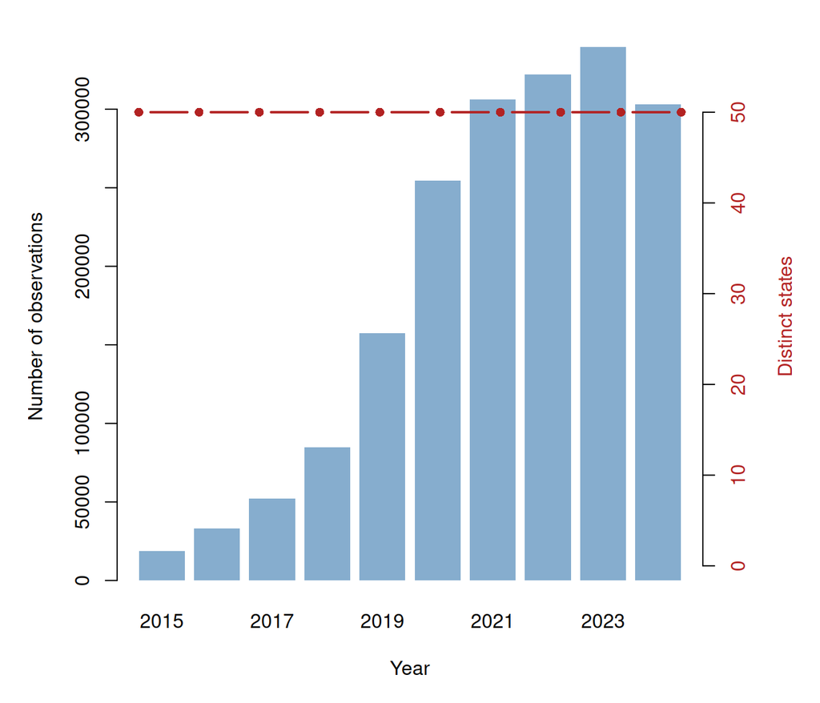

Figure 43: Annual US record volume and number of represented states

```r
years <- sort(unique(us_df$year))
year_obs <- sapply(years,function(y)sum(us_df$year==y))
year_states <- sapply(years,function(y)length(unique(us_df$state[us_df$year==y])))
coef <- max(year_obs)/max(year_states)
par(mar=c(5,5,2,5))
barplot(year_obs,names.arg=years,col=adjustcolor("steelblue",alpha.f=.65),
        border=NA,ylab="Number of observations",xlab="Year")
par(new=TRUE)
plot(seq_along(years),year_states,type="b",pch=16,lwd=2,col="firebrick",
     axes=FALSE,xlab="",ylab="",ylim=c(0,max(year_states)*1.1))
axis(4,col.axis="firebrick");mtext("Distinct states",side=4,line=3,col="firebrick")
```

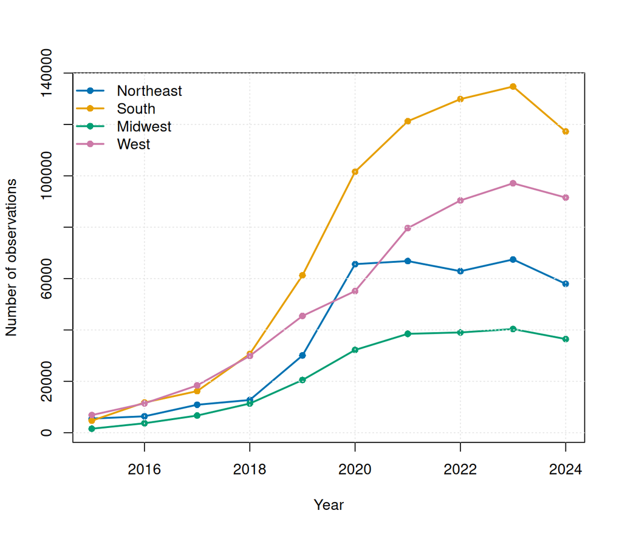

Figure 44: Yearly observation counts separated by US region

```r
yr <- table(us_df$year,us_df$region)
matplot(as.numeric(rownames(yr)),yr,type="o",pch=16,lty=1,lwd=2,
        col=region_colors[colnames(yr)],xlab="Year",ylab="Number of observations")
grid(col="grey90")
legend("topleft",legend=colnames(yr),col=region_colors[colnames(yr)],
       pch=16,lwd=2,bty="n")
```

The regional lines in Figure 44 do not grow in parallel. Most of the national increase comes from the South and West, whereas the Northeast and Midwest stay at lower levels. The regional imbalance is therefore repeated across several observation years rather than being produced by one exceptional year.

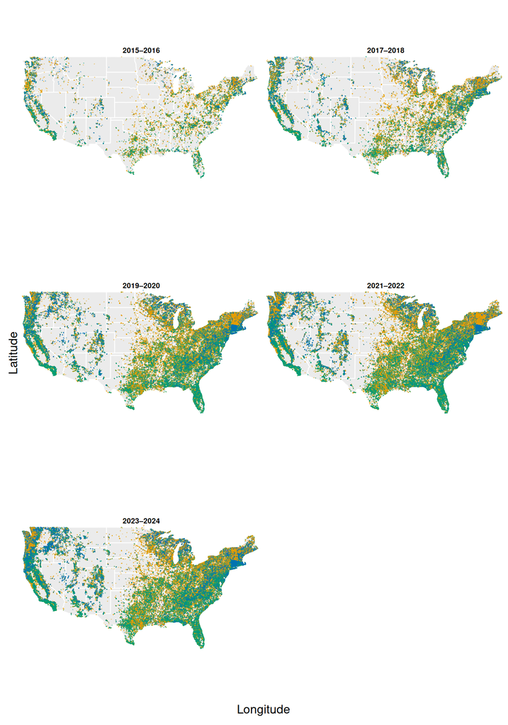

Figure 45: Spatial coverage of US observations across five observation periods

```r
us_df$period <- ifelse(us_df$year %in% c(2015,2016),"2015–2016",
             ifelse(us_df$year %in% c(2017,2018),"2017–2018",
             ifelse(us_df$year %in% c(2019,2020),"2019–2020",
             ifelse(us_df$year %in% c(2021,2022),"2021–2022","2023–2024"))))
periods <- c("2015–2016","2017–2018","2019–2020","2021–2022","2023–2024")
op <- par(mfrow=c(3,2),mar=c(1.5,1.5,2,.5),oma=c(2,2,0,0))
for(p in periods){
  z <- conus[conus$year %in% as.numeric(unlist(strsplit(p,"–")))[1]:
                           as.numeric(unlist(strsplit(p,"–")))[2],]
  draw_conus()
  points(z$longitude,z$latitude,pch=16,cex=.3,
         col=adjustcolor(foliage_colors[z$level0],alpha.f=.45))
  title(p,cex.main=.9)
}
plot.new()
mtext("Longitude",1,outer=TRUE);mtext("Latitude",2,outer=TRUE)
par(op)
```

The period maps in Figure 45 repeatedly show the same geographical cores, although the number of visible points increases. Coverage becomes denser more often than it becomes geographically broader. The dataset thus preserves a similar internal bias throughout the decade.

# 13 Overall Interpretation

This report has examined the GlobalGeoTree dataset from multiple angles — source bias, temporal trends, taxonomic composition, worldwide distribution, regional patterns in Germany, and a country-level analysis of the United States.

**Source bias and temporal trends.** The global analysis showed that citizen-science platforms — above all iNaturalist — dominate the dataset and strongly shape patterns by observation year and geography, making the combined dataset a composite of several geographically non-uniform “lenses” rather than a single coherent survey.

**Taxonomic composition and worldwide distribution.** The taxonomic analysis showed that Deciduous Broadleaf is the largest foliage category in the observations and that recorded species richness peaks in several temperate latitude bands. Sampling is heavily concentrated in North America and Europe, while regions such as central Africa, the Amazon interior, and Central Asia remain sparsely represented. This geographic bias is visible throughout 2015–2024 observation years, with later-dated records tending to intensify already represented areas rather than adding major new regions.

**Germany and Berlin analysis.** Within Germany, citizen-science dominance reproduces at the national level, but not with the same platforms: Pl@ntNet auto ID leads in Germany where iNaturalist leads globally, and Berlin reverts to iNaturalist again — each scale has a different dominant source. Federal state counts vary widely and closely follow the states’ populations, though the report does not normalise by population or area and so cannot separate tree cover from observer density. Berlin proves to be an extreme case: recording concentrates on a single forest, Grunewald, rather than on the urban tree stock a city-state might suggest, and Baden-Württemberg and NRW show this concentration is Berlin-specific. The Berlin oak analysis shows why GlobalGeoTree cannot support pest surveillance alone — the oak records track observer effort, so they are usable only over an official inventory with known coverage. Part II also surfaces a taxonomic fault inherited from the source dataset: roughly a tenth of German records carry family-rank keys behind species-looking names, and a bird ranks among the most-recorded “tree species”.

**United States.** The US analysis — the most-represented country in the dataset — showed strong regional imbalance in recording intensity, with the South and West contributing the largest shares of observations. Foliage composition varies geographically: Deciduous Broadleaf dominates everywhere, while Evergreen Broadleaf is more southern/coastal and Evergreen Needleleaf is more western and northern. Taxonomic richness remains partly shaped by sample size, so regional diversity comparisons should be read alongside the rarefaction results.

**Limitations and outlook.** All visualisations in this report show **recording intensity** in the dataset, not a direct census of trees. High values can reflect true tree presence, but they equally reflect where observers and platforms are most active. For any analysis built on GlobalGeoTree, the source composition of the sample should be reported alongside geographic, temporal, or taxonomic results, and key findings should be checked with and without the largest citizen-science source. Future work could refine the source classification rules, particularly for non-English source names, and explore whether the patterns observed in this analysis hold when the dominant citizen-science sources are excluded as a sensitivity check.

Because GlobalGeoTree aggregates tree observations from a large number of independent sources — citizen-science platforms, institutional herbarium and museum collections, systematic field inventories, compiled floristic atlases, and various research and conservation projects — it has no systematic global sampling design: it reflects where people happened to record trees, and its strong geographic, taxonomic, and temporal biases are source-driven rather than biologically meaningful. Observation patterns must therefore not be interpreted as direct measures of tree abundance. Three further caveats apply throughout the report. Every record reaches the dataset through GBIF, so a single observation re-published by more than one contributing dataset may appear under different source names despite the deduplication the authors applied; source classification is based on keyword rules and remains uncertain for multilingual or opaque source names; and the `year` field describes when an observation was recorded, not necessarily when it was added to GlobalGeoTree.

# References

Code for Germany. (n.d.). *Berlin district boundaries* [GeoJSON data file]. GitHub. https://github.com/codeforgermany/click_that_hood

European Commission, Eurostat. (2021). *NUTS – Nomenclature of territorial units for statistics: NUTS 2021 boundary data* [GeoJSON data files]. GISCO — Geographical Information System of the Commission. https://gisco-services.ec.europa.eu/distribution/v2/nuts/

GBIF Secretariat. (2024). *GBIF species API v1* [Application programming interface]. Global Biodiversity Information Facility. https://www.gbif.org/developer/species

Mu, Y., Xiong, Z., Wang, Y., Shahzad, M., Essl, F., Kreft, H., van Kleunen, M., & Zhu, X. X. (2025). GlobalGeoTree: A multi-granular vision-language dataset for global tree species classification. *arXiv preprint arXiv:2505.12513*. https://doi.org/10.48550/arXiv.2505.12513